# Programming for Data Analysis - Project

## Abstract

This Jupyter Python notebook explores a publicly-available dataset originating from the biennial Critical Assessment of protein Structure Prediction (CASP) competition, Series 5-9. After first performing exploratory data analysis on the dataset, different Python libraries are used to create a synthetic dataset. To this end, random numbers was generated to follow the distribution of each original attribute. Lastly, a visual comparison is made between the original and the synthetic dataset to evaluate the accurary of the entire data synthesis process. To provide reproducible results, the outputs of the synthesized values have been written as *comma-separated values* files.

1. Introduction
2. Exploratory Data Analysis (EDA)
3. Methods for Data Synthesis / Simulation
4. Generation of a synthetic dataset
5. RMSD
6. Total Surface Area
7. Non-polar exposed area
8. Fractional area of exposed non polar residue
9. Fractional area of exposed non polar part of residue
10. Molecular mass weighted exposed area
11. Average deviation from standard exposed area of residue
12. Euclidian distance
13. Secondary structure penalty
14. Spatial distribution constraints
15. Discussion
16. Conclusion

## Introduction

Proteins are complex molecules (macromolecules) responsible for performing a multitude of biological functions. These include:

| Protein name | Function |
| --- | --- |
| Keratin | Component of hair and nail |
| Collagen | Component of skin |
| Insulin | Responsible for regulating sugar and fat level |

An important aspect in the field of protein biochemistry is understanding how protein structures relate to their molecular function - which led to the emergence of the structural biology field. This active area of research applies experimental techniques such as [X-ray](https://en.wikipedia.org/wiki/X-ray_crystallography) and [neutron crystallography](https://en.wikipedia.org/wiki/Neutron_diffraction), and [electron microscopy](https://en.wikipedia.org/wiki/Electron_microscope) to determine the three-dimensional structures of protein such that questions on their evolutionary relationships and exploitability for healthcare can be answered.

However, experimental techniques suffer from inherent drawbacks - they require highly-pure and stable physical samples that can be difficult to obtain in sufficient quantities, as well as human expertise to convert data to three-dimensional models that can be instinctively interpreted by researchers from other fields. Computational biology approaches are one way to overcome these drawbacks. By making certain assumptions, we can [use computers to solve structures](https://en.wikipedia.org/wiki/Protein_structure_prediction). For instance, having solved one protein structure, we can predict that another similar protein will likely have the same overall structure, albeit with minor differences (homology modeling). Similar to other areas, machine learning techniques have been applied for protein structure prediction ([1](https://www.ncbi.nlm.nih.gov/pubmed/22274898) and 2).

Alternatively, we can also use fundamental physics to note that a certain protein sequence will only fold into a particular structure as there will be attraction and repulsion forces among the different atoms ([*de novo* prediction](https://en.wikipedia.org/wiki/De_novo_protein_structure_prediction)). The idea that there is no random sampling of all possible conformations during the process of protein folding is captured by [Levinthal's paradox](https://en.wikipedia.org/wiki/Levinthal%27s_paradox), where it was postulated that random sampling leading to the correct conformation would take more time than the age of the universe.

In order to judge the performance of various algorithms, [CASP](http://predictioncenter.org/) has been organized by the structural biology community as an open venue to learn from each other as often no one method is the best for *all* types of problems. Complementary techniques, including the use of lower resolution (less informative) tools such as circular dichroism, can also help to determine a model that is as close to the actual structure as possible.

In this notebook, we will look at the CASP dataset (obtained from the [UCI Machine Learning Repository](http://archive.ics.uci.edu/ml/datasets/Physicochemical+Properties+of+Protein+Tertiary+Structure)) and understand the relationship among all the variables and their individual distribtions before using tools in Python to generate a synthetic dataset that mimicks the experimental values. For reference, there are two publications related to the use of this dataset for machine learning and simulation ([1](https://www.researchgate.net/publication/310441738_Tight_Clustering_for_Large_Datasets_with_an_Application_to_Microarray_Data) and [2](https://dl.acm.org/citation.cfm?id=3029587)).

In order to not reinvent the wheel, we will use pre-existing Python libraries to achieve our goal.

```python
import numpy as np
import matplotlib.pyplot as plt
# %matplotlib notebook
%matplotlib inline
import pandas as pd
import seaborn as sns

# to make interactive plots with plotly
import plotly.figure_factory as ff
import plotly.graph_objs as go
from plotly.offline import download_plotlyjs, init_notebook_mode, iplot
init_notebook_mode(connected=True)
from plotly import tools

# original fitter is here: https://pypi.org/project/fitter/
# but we use https://github.com/caiostringari/fitter/tree/master
# (to install: pip install --upgrade https://github.com/caiostringari/fitter/tarball/master)
from fitter import Fitter

from pylab import *
from scipy.optimize import curve_fit
import scipy.interpolate as interpolate

# import scipy distributions that are needed later
from scipy.stats import moyal, exponnorm, johnsonsu, norm, genlogistic, invgauss, burr, mielke, t, fisk

# to make plotly images - https://plot.ly/python/static-image-export/
import plotly.io as pio
from IPython.display import Image
# https://community.plot.ly/t/use-plotly-offline-to-save-chart-as-image-file/408/41
pio.orca.config.port = 80 # in case firewall blocks access to the default port of 39167
```

## Exploratory Data Analysis (EDA)

We will first look at the data structure and make modifications as required.

```python
df = pd.read_csv('CASP.csv')
df
```

|  | RMSD | F1 | F2 | F3 | F4 | F5 | F6 | F7 | F8 | F9 |
| --- | --- | --- | --- | --- | --- | --- | --- | --- | --- | --- |
| 0 | 17.284 | 13558.30 | 4305.35 | 0.31754 | 162.1730 | 1.872791e+06 | 215.3590 | 4287.87 | 102 | 27.0302 |
| 1 | 6.021 | 6191.96 | 1623.16 | 0.26213 | 53.3894 | 8.034467e+05 | 87.2024 | 3328.91 | 39 | 38.5468 |
| 2 | 9.275 | 7725.98 | 1726.28 | 0.22343 | 67.2887 | 1.075648e+06 | 81.7913 | 2981.04 | 29 | 38.8119 |
| 3 | 15.851 | 8424.58 | 2368.25 | 0.28111 | 67.8325 | 1.210472e+06 | 109.4390 | 3248.22 | 70 | 39.0651 |
| 4 | 7.962 | 7460.84 | 1736.94 | 0.23280 | 52.4123 | 1.021020e+06 | 94.5234 | 2814.42 | 41 | 39.9147 |
| 5 | 1.700 | 5117.30 | 1120.99 | 0.21905 | 51.6732 | 6.727227e+05 | 79.5911 | 3234.21 | 15 | 41.2382 |
| 6 | 9.314 | 5924.16 | 1625.27 | 0.27434 | 70.2103 | 8.285145e+05 | 76.8064 | 2821.40 | 70 | 39.4964 |
| 7 | 1.985 | 6882.15 | 1791.22 | 0.26027 | 77.2501 | 9.165165e+05 | 96.6785 | 3490.88 | 74 | 37.4203 |
| 8 | 1.915 | 12090.00 | 4190.74 | 0.34662 | 129.0020 | 1.687508e+06 | 186.3090 | 4262.78 | 39 | 30.3916 |
| 9 | 1.495 | 7400.24 | 1881.95 | 0.25430 | 82.9320 | 1.023846e+06 | 104.6970 | 3852.40 | 26 | 35.4140 |
| 10 | 12.118 | 6556.77 | 1612.77 | 0.24597 | 71.6315 | 8.915443e+05 | 93.5329 | 3161.33 | 76 | 38.0433 |
| 11 | 0.884 | 8828.21 | 2658.63 | 0.30115 | 90.8578 | 1.233384e+06 | 123.6860 | 3194.30 | 22 | 37.2413 |
| 12 | 7.913 | 5637.37 | 2665.83 | 0.47288 | 49.8566 | 7.716355e+05 | 95.7431 | 2177.61 | 7 | 41.5268 |
| 13 | 14.103 | 9021.10 | 3097.91 | 0.34340 | 98.1155 | 1.244160e+06 | 121.3480 | 3396.40 | 32 | 37.0667 |
| 14 | 6.581 | 17572.20 | 5226.42 | 0.29742 | 227.7690 | 2.434431e+06 | 296.8000 | 4876.00 | 122 | 26.8169 |
| 15 | 6.110 | 12330.60 | 4380.20 | 0.35523 | 195.9300 | 1.710155e+06 | 232.1540 | 4321.41 | 164 | 30.4491 |
| 16 | 1.339 | 8478.55 | 2206.94 | 0.26029 | 91.5054 | 1.199770e+06 | 128.1660 | 3996.13 | 164 | 33.5263 |
| 17 | 2.554 | 9147.09 | 2828.26 | 0.30919 | 104.0500 | 1.291447e+06 | 131.3580 | 3595.69 | 17 | 35.5938 |
| 18 | 3.805 | 3905.51 | 1102.49 | 0.28229 | 34.2034 | 5.643988e+05 | 48.1646 | 1834.36 | 13 | 44.5123 |
| 19 | 18.645 | 15620.90 | 5834.18 | 0.37348 | 153.4760 | 2.184645e+06 | 251.2250 | 5441.50 | 101 | 26.0101 |
| 20 | 8.114 | 18679.00 | 5966.18 | 0.31940 | 179.7570 | 2.650897e+06 | 268.6610 | 6149.89 | 213 | 23.8081 |
| 21 | 18.404 | 13605.50 | 4766.37 | 0.35032 | 139.7930 | 1.925985e+06 | 182.1950 | 4672.34 | 112 | 26.4540 |
| 22 | 19.379 | 8693.56 | 3265.99 | 0.37567 | 55.4973 | 1.258363e+06 | 126.9280 | 4890.54 | 15 | 36.3849 |
| 23 | 17.598 | 7727.36 | 1370.27 | 0.17732 | 77.5656 | 1.035614e+06 | 103.1770 | 3130.45 | 27 | 37.1829 |
| 24 | 16.102 | 8865.32 | 3317.32 | 0.37419 | 95.8075 | 1.223688e+06 | 122.7480 | 3509.39 | 38 | 36.7233 |
| 25 | 14.923 | 8259.29 | 2719.28 | 0.32923 | 76.1237 | 1.087133e+06 | 122.1430 | 3763.75 | 58 | 35.5364 |
| 26 | 1.655 | 7136.22 | 2645.28 | 0.37068 | 64.1673 | 1.032920e+06 | 93.2759 | 3213.99 | 28 | 34.6186 |
| 27 | 4.128 | 6922.15 | 2143.02 | 0.30958 | 63.6012 | 9.896310e+05 | 91.6472 | 3146.95 | 31 | 38.8427 |
| 28 | 1.477 | 6449.78 | 1439.30 | 0.22315 | 74.7722 | 8.497845e+05 | 90.5322 | 3393.06 | 80 | 38.2100 |
| 29 | 2.165 | 13274.30 | 3989.12 | 0.30051 | 169.7460 | 1.855448e+06 | 198.6440 | 5089.76 | 67 | 26.6638 |
| ... | ... | ... | ... | ... | ... | ... | ... | ... | ... | ... |
| 45700 | 0.966 | 23403.50 | 5511.79 | 0.23551 | 319.1290 | 3.224178e+06 | 407.9570 | 6223.57 | 154 | 19.8365 |
| 45701 | 5.546 | 18403.60 | 4882.31 | 0.26529 | 245.5710 | 2.559338e+06 | 294.5570 | 5457.64 | 215 | 25.6038 |
| 45702 | 3.581 | 13696.00 | 4088.79 | 0.29853 | 145.3500 | 1.844331e+06 | 211.9420 | 4993.11 | 53 | 28.1334 |
| 45703 | 1.661 | 6405.36 | 2182.59 | 0.34074 | 72.0344 | 8.836039e+05 | 92.7146 | 3203.00 | 37 | 40.2693 |
| 45704 | 18.522 | 10840.30 | 5689.76 | 0.52487 | 85.2052 | 1.355167e+06 | 207.9200 | 2954.30 | 70 | 38.2021 |
| 45705 | 18.875 | 11215.80 | 3814.74 | 0.34012 | 102.4110 | 1.537030e+06 | 179.7740 | 4316.51 | 105 | 34.1568 |
| 45706 | 17.150 | 9779.31 | 3687.08 | 0.37702 | 82.2241 | 1.397476e+06 | 144.7080 | 4094.08 | 69 | 31.6338 |
| 45707 | 13.678 | 6233.61 | 846.29 | 0.13576 | 52.7953 | 8.656223e+05 | 71.4992 | 2733.96 | 45 | 34.9193 |
| 45708 | 4.758 | 6458.52 | 1380.97 | 0.21382 | 64.5865 | 8.980187e+05 | 72.4505 | 3220.17 | 34 | 38.0233 |
| 45709 | 1.788 | 6226.42 | 1551.74 | 0.24921 | 67.6087 | 8.793935e+05 | 74.1427 | 3131.57 | 14 | 38.9950 |
| 45710 | 3.509 | 13867.40 | 4320.27 | 0.31154 | 167.1120 | 1.923652e+06 | 216.2990 | 4917.21 | 72 | 28.5099 |
| 45711 | 1.572 | 8716.67 | 2369.97 | 0.27188 | 83.0696 | 1.222297e+06 | 116.8790 | 4092.53 | 49 | 33.9539 |
| 45712 | 8.221 | 9893.75 | 2426.80 | 0.24528 | 87.7843 | 1.396274e+06 | 124.5970 | 3957.71 | 153 | 33.4454 |
| 45713 | 12.684 | 7353.75 | 2471.99 | 0.33615 | 50.5474 | 1.047082e+06 | 107.5370 | 2965.32 | 68 | 39.5696 |
| 45714 | 17.180 | 9616.40 | 3410.33 | 0.35463 | 99.8179 | 1.353932e+06 | 150.5450 | 4188.42 | 60 | 35.1050 |
| 45715 | 0.984 | 9725.16 | 1990.64 | 0.20468 | 104.3870 | 1.372349e+06 | 138.4390 | 4324.37 | 50 | 30.6403 |
| 45716 | 3.619 | 10153.40 | 3390.35 | 0.33391 | 83.1698 | 1.410026e+06 | 154.4500 | 3871.40 | 33 | 34.1444 |
| 45717 | 13.697 | 6074.87 | 1322.94 | 0.21777 | 56.0178 | 8.186789e+05 | 70.0644 | 2471.63 | 38 | 41.4740 |
| 45718 | 11.283 | 3781.01 | 1149.39 | 0.30399 | 36.0219 | 5.128434e+05 | 47.6737 | 1391.45 | 32 | 44.4733 |
| 45719 | 4.540 | 5080.14 | 845.89 | 0.16650 | 54.8128 | 6.682106e+05 | 56.3293 | 2698.52 | 57 | 38.6640 |
| 45720 | 17.595 | 9583.84 | 2456.51 | 0.25631 | 57.4054 | 1.358302e+06 | 107.4720 | 4660.71 | 76 | 34.3923 |
| 45721 | 13.104 | 17178.30 | 5525.77 | 0.32167 | 159.8850 | 2.451261e+06 | 246.7130 | 5642.11 | 129 | 24.2395 |
| 45722 | 17.435 | 8651.89 | 3892.56 | 0.44990 | 87.6646 | 1.055050e+06 | 157.2490 | 2374.80 | 87 | 40.1504 |
| 45723 | 5.652 | 10345.10 | 3101.21 | 0.29977 | 105.9130 | 1.481496e+06 | 147.1010 | 4492.04 | 101 | 31.3618 |
| 45724 | 11.354 | 9106.35 | 2553.61 | 0.28042 | 72.1356 | 1.231680e+06 | 124.9890 | 4440.33 | 90 | 36.7669 |
| 45725 | 3.762 | 8037.12 | 2777.68 | 0.34560 | 64.3390 | 1.105797e+06 | 112.7460 | 3384.21 | 84 | 36.8036 |
| 45726 | 6.521 | 7978.76 | 2508.57 | 0.31440 | 75.8654 | 1.116725e+06 | 102.2770 | 3974.52 | 54 | 36.0470 |
| 45727 | 10.356 | 7726.65 | 2489.58 | 0.32220 | 70.9903 | 1.076560e+06 | 103.6780 | 3290.46 | 46 | 37.4718 |
| 45728 | 9.791 | 8878.93 | 3055.78 | 0.34416 | 94.0314 | 1.242266e+06 | 115.1950 | 3421.79 | 41 | 35.6045 |
| 45729 | 18.827 | 12732.40 | 4444.36 | 0.34905 | 157.6300 | 1.788897e+06 | 229.4590 | 4626.85 | 141 | 29.8118 |

45730 rows × 10 columns

From above, we can determine that we have 10 columns [RMSD (root mean square deviation) and F1-F9] of 45730 rows (data points) each. Except for the first column, the others are non-descriptive and should be renamed so avoid confusion later on.

For illustrative purposes, we do not really need all the 45730 rows, so it is possible to just use a random selection of about 50 % of the dataset using the `pandas.DataFrame.sample()` function. Because the Plotly plots are interactive and have the datapoints embedded within them, a smaller number of datapoints will allow for a smaller notebook size. A caveat of sampling is that it might result in an analysis not representative of the original dataset. Our strategy for handling a large dataset will be memory footprint optimization, [conversion of interactive plots to static images](https://plot.ly/python/static-image-export/) and large-enough random sampling.

To note, Plotly is capable of plotting hundreds of thousands of datapoints (big data) by using WebGL.

```python
# rename columns based on information from the UCI webpage
# F1 - Total surface area.
# F2 - Non polar exposed area.
# F3 - Fractional area of exposed non polar residue.
# F4 - Fractional area of exposed non polar part of residue.
# F5 - Molecular mass weighted exposed area.
# F6 - Average deviation from standard exposed area of residue.
# F7 - Euclidian distance.
# F8 - Secondary structure penalty.
# F9 - Spacial Distribution constraints (N,K Value). (typo for Spatial?)
df.rename(columns={'F1': 'Total surface area',
                   'F2': 'Non-polar exposed area',
                   'F3': 'Fractional area of exposed non-polar residue',
                   'F4': 'Fractional area of exposed non-polar part of residue',
                   'F5': 'Molecular mass weighted exposed area',
                   'F6': 'Average deviation from standard exposed area of residue',
                   'F7': 'Euclidian distance',
                   'F8': 'Secondary structure penalty',
                   'F9': 'Spatial Distribution constraints (N,K Value)'
                  }, inplace = True)

# if required, we can use just a subset of the dataset for faster plotting, fitting etc.
# df = df.iloc[:10000] # takes first 10000 rows
df = df.sample(n=int(len(df)/2), random_state=1) # random sample size of 50 % of the original df, seed=1
```

When dealing with large datasets, it is important to minimize the memory footprint. Several steps can be considered, but the most important one is to ensure the correct usage of datatypes, which can be examined using the `info()` function from Pandas.

```python
df.info(memory_usage='deep')
```

```
<class 'pandas.core.frame.DataFrame'>
Int64Index: 22865 entries, 13171 to 15355
Data columns (total 10 columns):
RMSD                                                       22865 non-null float64
Total surface area                                         22865 non-null float64
Non-polar exposed area                                     22865 non-null float64
Fractional area of exposed non-polar residue               22865 non-null float64
Fractional area of exposed non-polar part of residue       22865 non-null float64
Molecular mass weighted exposed area                       22865 non-null float64
Average deviation from standard exposed area of residue    22865 non-null float64
Euclidian distance                                         22865 non-null float64
Secondary structure penalty                                22865 non-null int64
Spatial Distribution constraints (N,K Value)               22865 non-null float64
dtypes: float64(9), int64(1)
memory usage: 1.9 MB
```

As we can see above, Pandas has imported the CASP dataset using float64 for almost all the variables. This is unnecessary as the output of `describe()` (not shown) indicate that we are dealing with smaller, positive values only. The [`to_numeric()` function](https://pandas.pydata.org/pandas-docs/stable/generated/pandas.to_numeric.html) with the *downcast* parameter will automatically select the most appropriate one.

```python
df['RMSD'] = pd.to_numeric(df['RMSD'], downcast='float')
df['Total surface area'] = pd.to_numeric(df['Total surface area'], downcast='unsigned')
df['Non-polar exposed area'] = pd.to_numeric(df['Non-polar exposed area'], downcast='float')

df['Fractional area of exposed non-polar residue'] = pd.to_numeric(df['Fractional area of exposed non-polar residue'],
                                                                   downcast='float')
df['Fractional area of exposed non-polar part of residue'] = pd.to_numeric(
                                            df['Fractional area of exposed non-polar part of residue'], downcast='float')

df['Molecular mass weighted exposed area'] = pd.to_numeric(df['Molecular mass weighted exposed area'], downcast='float')

df['Average deviation from standard exposed area of residue'] = pd.to_numeric(
    df['Average deviation from standard exposed area of residue'], downcast='float')

df['Euclidian distance'] = pd.to_numeric(df['Euclidian distance'], downcast='float')
df['Secondary structure penalty'] = pd.to_numeric(df['Secondary structure penalty'], downcast='unsigned')

df['Spatial Distribution constraints (N,K Value)'] = pd.to_numeric(
    df['Spatial Distribution constraints (N,K Value)'], downcast='float')
```

```python
df.info(memory_usage='deep')
```

```
<class 'pandas.core.frame.DataFrame'>
Int64Index: 22865 entries, 36510 to 18037
Data columns (total 10 columns):
RMSD                                                       22865 non-null float32
Total surface area                                         22865 non-null float64
Non-polar exposed area                                     22865 non-null float32
Fractional area of exposed non-polar residue               22865 non-null float32
Fractional area of exposed non-polar part of residue       22865 non-null float32
Molecular mass weighted exposed area                       22865 non-null float32
Average deviation from standard exposed area of residue    22865 non-null float32
Euclidian distance                                         22865 non-null float32
Secondary structure penalty                                22865 non-null uint16
Spatial Distribution constraints (N,K Value)               22865 non-null float32
dtypes: float32(8), float64(1), uint16(1)
memory usage: 1.1 MB
```

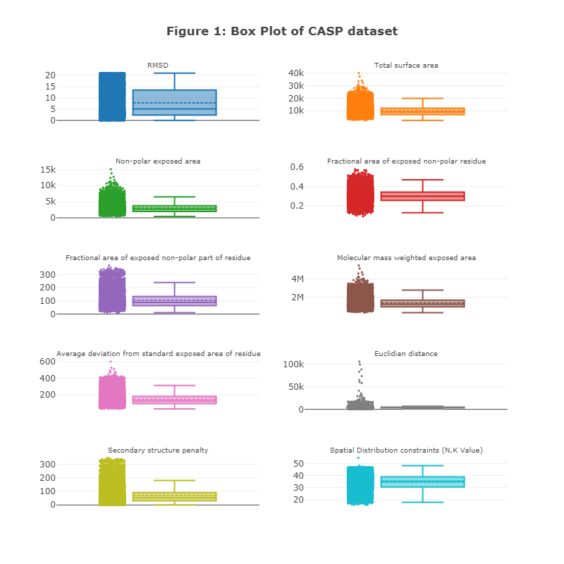

```python
trace0 = go.Box(y=df.iloc[:,0], marker = dict(size=3), boxpoints='all', boxmean = True)
trace1 = go.Box(y=df.iloc[:,1], marker = dict(size=3), boxpoints='all', boxmean = True)
trace2 = go.Box(y=df.iloc[:,2], marker = dict(size=3), boxpoints='all', boxmean = True)
trace3 = go.Box(y=df.iloc[:,3], marker = dict(size=3), boxpoints='all', boxmean = True)
trace4 = go.Box(y=df.iloc[:,4], marker = dict(size=3), boxpoints='all', boxmean = True)
trace5 = go.Box(y=df.iloc[:,5], marker = dict(size=3), boxpoints='all', boxmean = True)
trace6 = go.Box(y=df.iloc[:,6], marker = dict(size=3), boxpoints='all', boxmean = True)
trace7 = go.Box(y=df.iloc[:,7], marker = dict(size=3), boxpoints='all', boxmean = True)
trace8 = go.Box(y=df.iloc[:,8], marker = dict(size=3), boxpoints='all', boxmean = True)
trace9 = go.Box(y=df.iloc[:,9], marker = dict(size=3), boxpoints='all', boxmean = True)

# we have to make subplots because the scales are different for the variables
fig = tools.make_subplots(rows=5, cols=2, print_grid=False,
                          subplot_titles= (df.columns[0], df.columns[1], df.columns[2], df.columns[3],
                                           df.columns[4], df.columns[5], df.columns[6], df.columns[7],
                                           df.columns[8], df.columns[9]
                                                          ))

fig.append_trace(trace0, 1, 1)
fig.append_trace(trace1, 1, 2)
fig.append_trace(trace2, 2, 1)
fig.append_trace(trace3, 2, 2)
fig.append_trace(trace4, 3, 1)

fig.append_trace(trace5, 3, 2)
fig.append_trace(trace6, 4, 1)
fig.append_trace(trace7, 4, 2)
fig.append_trace(trace8, 5, 1)
fig.append_trace(trace9, 5, 2)

fig['layout'].update(height=800, width=800, title='<b>Figure 1: Box Plot of CASP dataset</b>')
fig['layout'].update(showlegend=False)

# https://github.com/plotly/plotly.py/issues/985
for i in fig['layout']['annotations']:
    i['font'] = dict(size=10)

for prop in fig.layout:
    if prop.startswith('xaxis'):
        # don't really need both xaxis label and subplot title, so turn xaxis label off
        fig.layout[prop].showticklabels = False

config = {
'include_plotlyjs': False
}

# iplot(fig)
img_bytes = pio.to_image(fig, format='png')
Image(img_bytes)
```

The sampled dataset do not have many outliers, as shown by the box plots above. Most of these are present in the Euclidian distance variable. Moreover, the mean of almost all variables are very close to the median (middle 50 % of the dataset), including a normal-like distribution. An exception could be the RMSD variable.

Although a table containing the correlation coefficents between two variables for all the variables can be obtained by using `pandas.DataFrame.corr()` function, it is too 'numerical' for a good interpretation. A better option is to use Seaborn to construct a heat map based on the data from `pandas.DataFrame.corr()`.

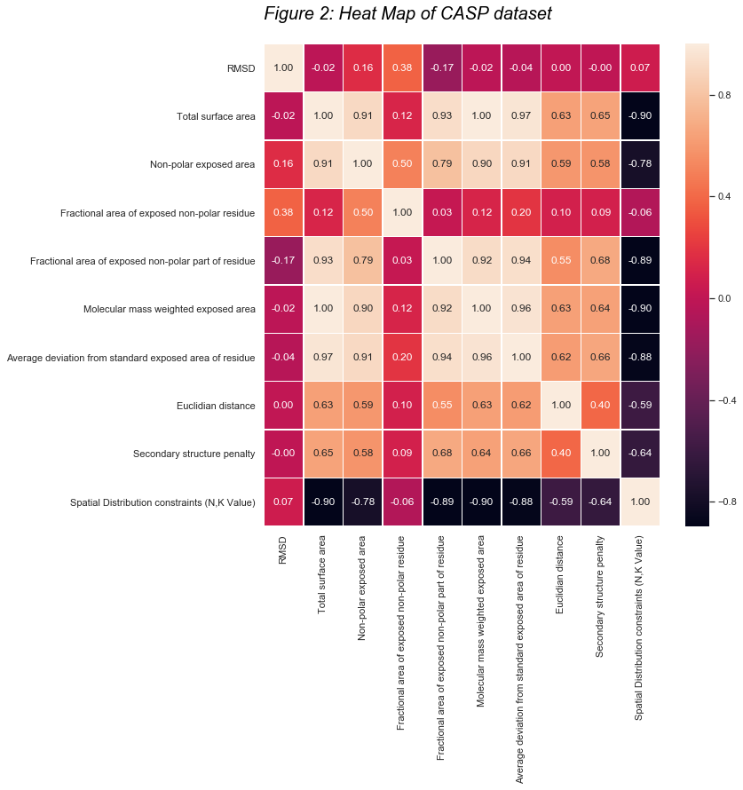

```python
sns.set(font_scale=1)
plt.figure(figsize=(10,10))
plt.text(0,-0.5, "Figure 2: Heat Map of CASP dataset", fontsize = 20, color='Black', fontstyle='italic')
# plt.tight_layout()

# according to the docs https://seaborn.pydata.org/generated/seaborn.heatmap.html and
# http://alanpryorjr.com/visualizations/seaborn/heatmap/heatmap/
# we can use linewidths to create some spacing between the cells and
# fmt (format) to round 2 decimal points

# https://stackoverflow.com/questions/25790062/
sns.heatmap(df.corr(), annot=True, linewidths = 0.5, fmt='.2f');
```

To complement the heat map, a scatterplot matrix can be employed for pairwise comparison.

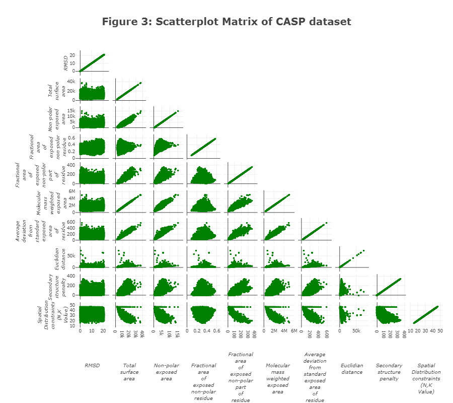

```python
# https://community.plot.ly/t/splom-scatter-matrix-changing-styles-of-all-axes-in-one-go/16636/2
# https://plot.ly/python/splom/

# initiate placeholders
dataPanda = []
label = ''

for column in list(df.columns):

    columnSplit = column.split(' ') # create a list of string from the column name

    for i in columnSplit:
        label = label + i + '<br>' # as plotly uses JavaScript, we can use the html <br> tag to split line

    # inspired by: https://stackoverflow.com/questions/43229013/
    for i in range(3):
        label = '<br>' + label + '<br>'

    label = '<i>' + label + '</i>'
    trace = dict(label = label, values = df[column])

    dataPanda.append(trace)
    label = '' # reset the variable for next for iteration

trace1 = go.Splom(dimensions=dataPanda, showupperhalf=False, marker=dict(size=3, color='green'))
data = [trace1]

layout = go.Layout(title = '<b>Figure 3: Scatterplot Matrix of CASP dataset</b>',
                font=dict(size=8.5), # global font
                titlefont=dict(size=20), # but we want only title to have different size
                # layout control- left, right, bottom, top (t) and padding (pad )
                margin = dict(l = 150, r = 20, b = 150)
                )

fig = go.Figure(data=data, layout=layout)
fig['layout'].update(height=800, width=900)

# iplot(fig)
img_bytes = pio.to_image(fig, format='png')
Image(img_bytes)
```

Based on the variable labels and the correlation coefficients above, it seems likely that some variables could be collinear, rather than truly correlated. For instance, the non-polar exposed area, fractional area of exposed non-polar residue and fractional area of exposed non-polar part of residue are probably calculations by related equations.

## Methods for Data Synthesis / Simulation

In any case, we should look at the distribution of each variable. Scipy comes with built-in functions for probability distribution functions (PDF) for many well-known distributions. Each function takes usually two parameters - *scale* to control peak height and *loc* to control the mean (see the Jupyter notebook in the ProgrammingforDA-Assignment repository).

While we could manually fit each distribution for each variable, we can use the `fitter` module to automatically generate the curves for us. In essence, `fitter` uses Scipy curve_fit to perform non-linear least square fitting with initial parameters estimated from the data.

A synthetic dataset can be generated by the following methods:

1. For dataset related to a specific chemical or physical phenomenon, the relationship between the response and predictor variables can often be described as a mathematical equation (first principles and/or mechanistic model). Usually, the model takes the form of a differential equation. In this case, an error term referencing random numbers (noise) can be added to that model to yield a synthetic dataset.
2. For those that do not have a mathematical equation defined in the literature but follows a well-described and widely used distribution, we can use one of the [35+ `numpy.random` functions](https://docs.scipy.org/doc/numpy/reference/routines.random.html), for example `numpy.random.beta()`. Alternatively, a larger set of functions from [`scipy.stats` (about 80 functions)](http://scipy.github.io/devdocs/stats.html) can be used, for example `scipy.stats.rvs()`.

   However, we need to know the parameters, such as $\mu$ and $\sigma$ for the mean and standard deviation for a normal distribution, respectively, . This can be estimated by 'eye', trial-and-error or automated/manual curve fitting. In this project, the [Fitter package](https://pythonhosted.org/fitter/) will be used. Fitter is essentially a wrapper module around `scipy.stats` as the probability distribution source and `scipy.optimize.curve_fit()` for non-linear least squares curve fitting, which can rapidly achieve convergence given initial parameter estimates that roughly match the actual parameter values for the corresponding probability distribution function (PDF).

   Note that the [original GitHub repository for this package](https://github.com/cokelaer/fitter) was last updated about 2 years. Therefore, a [different branch](https://github.com/caiostringari/fitter/tree/master) with more recent updates aligned to the latest Matplotlib library will be used. For installation, use the following command in shell: `pip install --upgrade https://github.com/caiostringari/fitter/tarball/master` (`--upgrade` can be omitted if installing for the first time).

   Simulating a dataset following a bimodal normal distribution is difficult with `numpy.random` but [doable](https://stackoverflow.com/questions/4265988/generate-random-numbers-with-a-given-numerical-distribution).
3. For these difficult cases where there are no well-known distributions, [inverse transform sampling (ITS)](http://www.nehalemlabs.net/prototype/blog/2013/12/16/how-to-do-inverse-transformation-sampling-in-scipy-and-numpy/) can be employed.
   1. [Inverse transform sampling](https://en.wikipedia.org/wiki/Inverse_transform_sampling), in essence, is a method to rescale a uniform random variable (which is what numpy.random returns - see the Programming for Data Analysis Assignment) into a desired probability distribution.
   2. The cumulative distribution function (CDF) can be thought of as the integral of the data histogram [which itself is a (PDF)], giving us [the percentage or the relative count plotted against the data](https://www.andata.at/en/software-blog-reader/why-we-love-the-cdf-and-do-not-like-histograms-that-much.html). CDF has a $y$ axis of [0,1].
   3. Inverting the CDF allows the sampling of the uniform values because the y-axis is turned into an x-axis of [0,1], followed by a transformation into the target distribution.

### Model selection

Oftentimes, replication of experimental distributions are not faithfully reproducible by standard probability distributions even with low error values (sum of the squared difference between the predicted and observed values). In other cases, there could be multiple suitable models with similar error values. From basic statistics, we know that fitting more complicated models come with the risk of fitting noise (for example, measurement errors in the experimental data).

Two related penalty functions for comparing models are the [Akaike information criterion (AIC)](https://en.wikipedia.org/wiki/Akaike_information_criterion) and [Bayesian information criterion (BIC)](https://en.wikipedia.org/wiki/Bayesian_information_criterion), with the latter imposing a higher penalty. For both, the absolute values are not important but rather, a model with a lower AIC/BIC value is considered more parsimonious and preferable. More details are available in the work by [Fabozzi *et al.* (2014)](https://onlinelibrary.wiley.com/doi/pdf/10.1002/9781118856406.app5). In this notebook, the AIC/BIC values will be compared with the error values to determine the most appropriate distribution to be used for generating a synthetic dataset.

```python
# http://www.nehalemlabs.net/prototype/blog/2013/12/16/how-to-do-inverse-transformation-sampling-in-scipy-and-numpy/

# increase n_bins and samples to get a better sampling
def inverse_transform_sampling(data, n_bins = 200, n_samples = len(df)):

    # calculate a histogram over the data. density = True calc's a pdf
    hist, bin_edges = np.histogram(data, bins = n_bins, density=True)

    cum_values = np.zeros(bin_edges.shape) # return an array filled with zeros with the dimension of the bin_edges above
    cum_values[1:] = np.cumsum(hist*np.diff(bin_edges)) # cumulative sum of histogram x discrete difference

    inv_cdf = interpolate.interp1d(cum_values, bin_edges) # interpolate over the cumulative sum
    r = np.random.rand(n_samples) # generate a bunch of random numbers

    return inv_cdf(r) # return the random numbers shaped from the interpolate result above
```

## Generation of a synthetic dataset

For clarity, each column will be synthesized using one or more standard Scipy distributions and ITS followed by a graphical distribution comparison to the original (experimental) data. In the end, these synthetic columns will be assembled as a Pandas dataframe and corresponding box plots and scatter matrices generated.

### RMSD

```python
RMSD_values = df['RMSD'] # get all RMSD values

f_RMSD = Fitter(RMSD_values)
f_RMSD.fit()
```

[output not shown]

```
Fitted alpha distribution with error=0.11631537349566168, AIC=787.6541508807237, BIC=811.7662387890002)
Fitted anglit distribution with error=0.19276851456375033, AIC=643.8353809189516, BIC=659.9101061911359)
Fitted arcsine distribution with error=0.24309575085678953, AIC=644.9283391864687, BIC=661.0030644586531)
Fitted argus distribution with error=0.20891487068510717, AIC=632.8929130702172, BIC=657.0050009784936)
Fitted beta distribution with error=0.13526581212944883, AIC=630.8470278456356, BIC=662.9964783900042)
```

[output not shown]

```
Fitted betaprime distribution with error=0.10488235852903133, AIC=679.0511385637383, BIC=711.2005891081069)
Fitted bradford distribution with error=0.13715540058853243, AIC=617.9689058856807, BIC=642.0809937939571)
Fitted burr distribution with error=0.13883726987919984, AIC=669.451731895358, BIC=701.6011824397266)
Fitted burr12 distribution with error=0.11060255689983448, AIC=674.2171494329822, BIC=706.3665999773508)
Fitted cauchy distribution with error=0.15504248117711472, AIC=780.9505544870893, BIC=797.0252797592736)
Fitted chi distribution with error=0.12922977015357104, AIC=664.5358968695555, BIC=688.6479847778319)
Fitted chi2 distribution with error=0.7348728447419687, AIC=950.8555753912547, BIC=974.9676632995311)
Fitted cosine distribution with error=0.19527444399582342, AIC=654.8639856923106, BIC=670.9387109644949)
```

[output not shown]

```
Fitted crystalball distribution with error=0.19751263949979758, AIC=672.4560178492272, BIC=704.6054683935959)
Fitted dgamma distribution with error=0.1533304119009997, AIC=695.6076715530654, BIC=719.7197594613419)
Fitted dweibull distribution with error=0.13524938685194957, AIC=689.3572860112448, BIC=713.4693739195213)
Fitted erlang distribution with error=0.10476519617346725, AIC=676.9565215168249, BIC=701.0686094251014)
Fitted expon distribution with error=0.11843827707173928, AIC=684.5054757657238, BIC=700.5802010379081)
```

[output not shown]

[output cut: 884 more lines]

[output not shown]

```
Fitted exponnorm distribution with error=0.07122365108652987, AIC=689.2286832028907, BIC=713.3407711111672)
Fitted exponpow distribution with error=0.12947347373429055, AIC=656.5327693360075, BIC=680.6448572442839)
Fitted exponweib distribution with error=0.12886462606685542, AIC=665.1187242840754, BIC=697.268174828444)
Fitted f distribution with error=0.24476060874774452, AIC=762.8578701751305, BIC=795.0073207194991)
Fitted fatiguelife distribution with error=0.07643887009228663, AIC=694.3230309776778, BIC=718.4351188859544)
Fitted fisk distribution with error=0.09085124940788687, AIC=709.4556969060047, BIC=733.5677848142811)
Fitted foldcauchy distribution with error=0.10943837452673223, AIC=724.0689909834591, BIC=748.1810788917355)
Fitted foldnorm distribution with error=0.1283367823691229, AIC=657.3241661557171, BIC=681.4362540639936)
Fitted frechet_l distribution with error=1.3671080245441556, AIC=884.9102279562394, BIC=909.0223158645158)
Fitted frechet_r distribution with error=0.29422151278557873, AIC=739.7548422894129, BIC=763.8669301976893)
Fitted gamma distribution with error=0.10476611120994918, AIC=676.9557579278209, BIC=701.0678458360974)
```

[output not shown]

```
Fitted gausshyper distribution with error=0.1074942851012003, AIC=639.8777118959185, BIC=688.1018877124715)
Fitted genexpon distribution with error=0.09215180664121385, AIC=687.3486961113448, BIC=727.5355092918055)
Fitted genextreme distribution with error=0.08340683326568019, AIC=717.5351699218693, BIC=741.6472578301457)
Fitted gengamma distribution with error=0.13539405741454874, AIC=663.8688932154845, BIC=696.0183437598531)
Fitted genhalflogistic distribution with error=0.14096146671270463, AIC=650.2852355632026, BIC=674.397323471479)
Fitted genlogistic distribution with error=0.16431992828800812, AIC=680.7415034176859, BIC=704.8535913259623)
Fitted gennorm distribution with error=0.16380449140776707, AIC=620.6195627683715, BIC=644.7316506766479)
```

[output not shown]

[output not shown]

[output not shown]

```
SKIPPED ksone distribution(taking more than 30 seconds)
Fitted kstwobign distribution with error=0.16084051513998554, AIC=670.4056968220672, BIC=686.4804220942515)
Fitted laplace distribution with error=0.18149050053051569, AIC=728.3828229440606, BIC=744.457548216245)
Fitted levy distribution with error=0.10308224311224408, AIC=769.0559489182906, BIC=785.1306741904749)
Fitted levy_l distribution with error=0.2828879928300592, AIC=771.9203034011894, BIC=787.9950286733737)
```

[output not shown]

```
SKIPPED levy_stable distribution(taking more than 30 seconds)
Fitted loggamma distribution with error=0.19721477008822844, AIC=670.0638024978842, BIC=694.1758904061608)
Fitted logistic distribution with error=0.19850477430701408, AIC=682.3604849807748, BIC=698.4352102529591)
```

[output not shown]

```
Fitted loglaplace distribution with error=0.42169694280895387, AIC=839.722204120245, BIC=863.8342920285215)
Fitted lognorm distribution with error=0.08426409356382847, AIC=700.717172843455, BIC=724.8292607517315)
Fitted lomax distribution with error=0.12104643825640862, AIC=695.1634614479029, BIC=719.2755493561795)
Fitted maxwell distribution with error=0.1837377031355419, AIC=664.5754741282772, BIC=680.6501994004615)
```

[output not shown]

```
Fitted mielke distribution with error=0.07924327190770933, AIC=722.5434347166578, BIC=754.6928852610264)
Fitted moyal distribution with error=0.1444351955215317, AIC=684.2258462720207, BIC=700.300571544205)
Fitted nakagami distribution with error=0.1285384145482213, AIC=669.7254487472038, BIC=693.8375366554803)
```

[output not shown]

```
SKIPPED ncf distribution(taking more than 30 seconds)
SKIPPED nct distribution(taking more than 30 seconds)
SKIPPED ncx2 distribution(taking more than 30 seconds)
Fitted norm distribution with error=0.19751263810815886, AIC=668.4560182539798, BIC=684.5307435261641)
Fitted norminvgauss distribution with error=0.07855845296741956, AIC=702.1644832958824, BIC=734.313933840251)
Fitted pareto distribution with error=0.11884779262588767, AIC=687.0826854618331, BIC=711.1947733701095)
Fitted pearson3 distribution with error=0.10476603188404154, AIC=676.9558252078366, BIC=701.067913116113)
Fitted powerlaw distribution with error=0.16862929831891738, AIC=635.0187376179598, BIC=659.1308255262363)
```

[output not shown]

```
Fitted powerlognorm distribution with error=0.09098882422164196, AIC=698.6353639584796, BIC=730.7848145028482)
```

[output not shown]

```
Fitted powernorm distribution with error=nan, AIC=662.8402427262754, BIC=686.9523306345518)
Fitted rayleigh distribution with error=0.1772366951139294, AIC=660.9433356342151, BIC=677.0180609063995)
Fitted rdist distribution with error=0.16816154605384767, AIC=615.5872975933057, BIC=639.6993855015821)
Fitted recipinvgauss distribution with error=0.08315797843359732, AIC=688.8040647364312, BIC=712.9161526447076)
```

[output not shown]

```
Fitted reciprocal distribution with error=0.39625631916423487, AIC=inf, BIC=inf)
Fitted rice distribution with error=0.1772371013030185, AIC=662.943674757014, BIC=687.0557626652906)
SKIPPED rv_continuous distribution(taking more than 30 seconds)
SKIPPED rv_histogram distribution(taking more than 30 seconds)
Fitted semicircular distribution with error=0.18774125934358676, AIC=626.1890695837377, BIC=642.263794855922)
Fitted skewnorm distribution with error=0.11576624685361314, AIC=661.9884854397284, BIC=686.1005733480049)
Fitted t distribution with error=0.19751985704084707, AIC=670.4536792204831, BIC=694.5657671287595)
Fitted trapz distribution with error=0.2940204561467141, AIC=681.7819349140374, BIC=713.931385458406)
Fitted triang distribution with error=0.10748607459570461, AIC=647.1993933585185, BIC=671.311481266795)
Fitted truncexpon distribution with error=0.1336305411250901, AIC=619.4155106413361, BIC=643.5275985496125)
```

[output not shown]

```
Fitted truncnorm distribution with error=0.19751264044557398, AIC=672.4560166371116, BIC=704.6054671814802)
```

[output not shown]

```
SKIPPED tukeylambda distribution(taking more than 30 seconds)
Fitted uniform distribution with error=0.16923987526987816, AIC=612.88543901855, BIC=628.9601642907343)
Fitted vonmises distribution with error=4.003227524934667e+55, AIC=-12249.465587300925, BIC=-12225.353499392648)
Fitted vonmises_line distribution with error=0.16923988125482564, AIC=614.9177445892464, BIC=639.0298324975229)
Fitted wald distribution with error=0.07186774326386595, AIC=700.9441738258258, BIC=717.0188990980101)
Fitted weibull_max distribution with error=1.3671080245441556, AIC=884.9102279562394, BIC=909.0223158645158)
Fitted weibull_min distribution with error=0.29422151278557873, AIC=739.7548422894129, BIC=763.8669301976893)
Fitted wrapcauchy distribution with error=nan, AIC=nan, BIC=nan)
```

[output not shown]

|  | sumsquare_error | AIC | BIC |
| --- | --- | --- | --- |
| exponnorm | 0.071224 | 689.228683 | 713.340771 |
| wald | 0.071868 | 700.944174 | 717.018899 |
| gilbrat | 0.074893 | 702.230456 | 718.305181 |
| fatiguelife | 0.076439 | 694.323031 | 718.435119 |
| norminvgauss | 0.078558 | 702.164483 | 734.313934 |

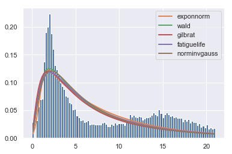

```python
f_RMSD.summary()
```

Based on the plot above, it is clear that none of the distributions in `scipy.stats` module fits the RMSD data with the default bin size. We can try increasing the bins size.

```python
f_RMSD = Fitter(RMSD_values, bins = 100) # can pass xmin = 7.5 if needed
f_RMSD.fit()
```

[output not shown]

[output cut: 45 more lines]

[output not shown]

|  | sumsquare_error | AIC | BIC |
| --- | --- | --- | --- |
| exponnorm | 0.071224 | 689.228683 | 713.340771 |
| wald | 0.071868 | 700.944174 | 717.018899 |
| gilbrat | 0.074893 | 702.230456 | 718.305181 |
| fatiguelife | 0.076439 | 694.323031 | 718.435119 |
| norminvgauss | 0.078558 | 702.164483 | 734.313934 |

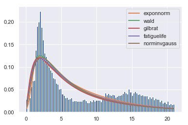

```python
f_RMSD.summary()
```

Unfortunately, automatic fitting has failed on the RMSD data. More likely, this is a bimodal normal distribution with a mean of about 3 and 15. In this instance, we will have to manually define two normal distributions following by curve fitting.

```
[  2.15343859   0.86642361 401.06184843  11.75858425  -9.89387758
  87.6740905 ]
 [ 0.0282778   0.03797205 13.47084028  0.82197174  1.7028006   4.22117304]
```

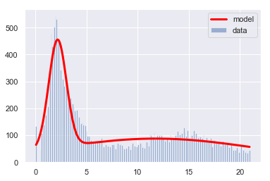

```python
# https://stackoverflow.com/questions/37559470/what-do-all-the-distributions-available-in-scipy-stats-look-like
# https://stackoverflow.com/questions/35990467/fit-two-gaussians-to-a-histogram-from-one-set-of-data-python

# https://matplotlib.org/api/_as_gen/matplotlib.pyplot.hist.html
# hist() returns a tuple, with the last element being a silent list of patches,
# so we assign this to special variable '_'
# https://hackernoon.com/understanding-the-underscore-of-python-309d1a029edc
# https://docs.scipy.org/doc/scipy/reference/generated/scipy.optimize.curve_fit.html
# https://docs.scipy.org/doc/numpy/reference/generated/numpy.diag.html

y, x, _ = hist(df['RMSD'], 200, alpha = 0.5, label = 'data')

x = (x[1:] + x[:-1]) / 2 # for len(x)==len(y)

def gauss(x, mu, sigma, A):
    return A*exp(-(x - mu) **2 / 2 / sigma**2)

def bimodal(x, mu1, sigma1, A1, mu2, sigma2, A2):
    return gauss(x, mu1, sigma1, A1) + gauss(x, mu2, sigma2, A2)

# initial estimates for non-linear least square
# we define the parameters from estimating by eye:
# Normal Distribution 1 - mean = 3, standard deviation = 0.5 and scale of 800
# Normal Distribution 2 - mean = 15, standard deviation = 9 and scale of 150
expected = (3, 0.5, 800, 15, 9, 150)

# curve_fit returns popt (array of optimal params) and pcov (array of est covariance of popt)
params, cov = curve_fit(bimodal, x, y, expected)
sigma = sqrt(diag(cov))

plot(x, bimodal(x, *params), color='red', lw=3, label='model')
legend()

print(params, '\n', sigma)
```

From the output above, we obtain two normal distributions that is relatively a good approximation of the RMSD data.

*HTML code is used for rendering the table below because of some bugs in Markdown/Jupyter for center alignment.*

| Distribution | $\mu$ | $\sigma$ | A (scale) |
| --- | --- | --- | --- |
| Normal1 | 2.15 | 0.87 | 401.06 |
| Normal2 | 11.76 | 9.89 | 87.67 |

However, while we can describe the data as an additive function of two normal distributions, this whole process of providing initial estimates and performing function addition is quite cumbersome and not really amenable for automation. As such, ITS is a better option to generate random values for RMSD. To note, [Monte Carlo rejection sampling could also be used](https://stackoverflow.com/questions/41470070/python-random-sampling-from-self-defined-probability-function).

```python
RMSD_ITS = inverse_transform_sampling(df['RMSD'])

# reduce the variable memory footprint
# https://docs.scipy.org/doc/numpy-1.9.0/reference/generated/numpy.ndarray.astype.html
RMSD_ITS = RMSD_ITS.astype(dtype = 'float32', casting = 'same_kind')
```

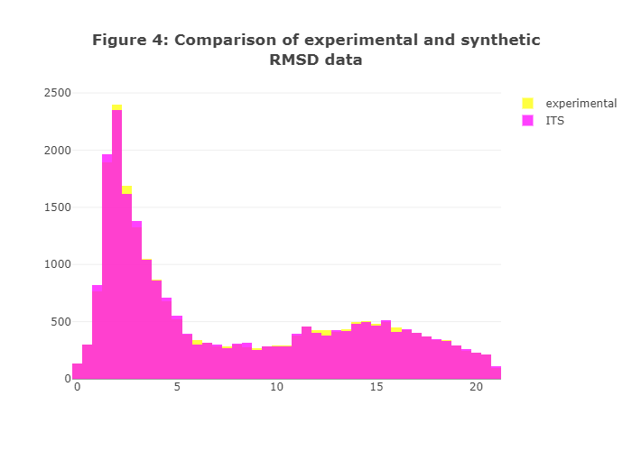

```python
# https://plot.ly/python/histograms/

trace_experimental = go.Histogram(x = df['RMSD'], opacity= 0.75, name = 'experimental', marker = dict(color = 'yellow'))
trace_ITS = go.Histogram(x = RMSD_ITS, opacity= 0.75, name = 'ITS', marker = dict(color = 'magenta'))

data = [trace_experimental, trace_ITS]

layout = go.Layout(barmode= 'overlay', title = '<b>Figure 4: Comparison of experimental and synthetic<br>RMSD data</b>')

fig = go.Figure(data=data, layout=layout)
# iplot(fig)

img_bytes = pio.to_image(fig, format='png')
Image(img_bytes)
```

By visual comparison, we can be confident that ITS provides a good approximation of the experimental dataset and that the random values hence generated follows the original distribution.

### Total Surface Area

Let us now look at the Total Surface Area data.

```python
data = df['Total surface area']

f_TotalSurfaceArea = Fitter(data, bins=200)
f_TotalSurfaceArea.fit()
```

```
Fitted alpha distribution with error=1.0478016182660564e-08, AIC=4836.504044685137, BIC=4860.616132593414)
Fitted anglit distribution with error=2.691256504249789e-07, AIC=4304.669976582023, BIC=4320.744701854207)
```

[output not shown]

```
Fitted arcsine distribution with error=4.2362253955991655e-07, AIC=4252.917175124052, BIC=4268.991900396236)
Fitted argus distribution with error=4.018623983461105e-07, AIC=4230.436159188017, BIC=4254.548247096293)
```

[output not shown]

```
Fitted beta distribution with error=1.19253663649438e-08, AIC=5051.151715004125, BIC=5083.301165548494)
Fitted betaprime distribution with error=8.658083517404978e-09, AIC=4822.089627119727, BIC=4854.239077664096)
Fitted bradford distribution with error=2.2256915312590553e-07, AIC=4273.480238085705, BIC=4297.592325993982)
Fitted burr distribution with error=1.8963417825992672e-08, AIC=4701.385610530255, BIC=4733.535061074624)
Fitted burr12 distribution with error=1.333440434533281e-08, AIC=4785.561818312838, BIC=4817.711268857207)
Fitted cauchy distribution with error=4.298806659538157e-08, AIC=4756.638025225648, BIC=4772.712750497832)
Fitted chi distribution with error=6.055610091630982e-08, AIC=6181.624798840752, BIC=6205.736886749029)
Fitted chi2 distribution with error=1.6302001995893303e-08, AIC=5243.453402858791, BIC=5267.565490767068)
Fitted cosine distribution with error=2.2441164497822283e-07, AIC=4452.9672319367255, BIC=4469.0419572089095)
Fitted crystalball distribution with error=4.7136028022213187e-07, AIC=inf, BIC=inf)
Fitted dgamma distribution with error=4.437036971198926e-08, AIC=5227.7631465581735, BIC=5251.87523446645)
Fitted dweibull distribution with error=4.789694082233307e-08, AIC=5345.893110169589, BIC=5370.005198077865)
```

[output not shown]

[output cut: 2332 more lines]

[output not shown]

```
Fitted erlang distribution with error=3.987697022531147e-08, AIC=5720.289974311106, BIC=5744.402062219382)
Fitted expon distribution with error=2.0993258875442315e-07, AIC=4534.776381387949, BIC=4550.851106660133)
Fitted exponnorm distribution with error=8.945773381055425e-09, AIC=4833.083546131788, BIC=4857.195634040065)
```

[output not shown]

[output not shown]

[output not shown]

```
Fitted mielke distribution with error=4.776466468662414e-08, AIC=4482.127646599927, BIC=4514.277097144296)
Fitted moyal distribution with error=8.402316212981134e-09, AIC=4888.113879261367, BIC=4904.188604533551)
Fitted nakagami distribution with error=2.7248298095713998e-08, AIC=5548.319332859219, BIC=5572.431420767495)
SKIPPED ncf distribution(taking more than 30 seconds)
```

[output not shown]

[output not shown]

|  | sumsquare_error | AIC | BIC |
| --- | --- | --- | --- |
| moyal | 8.402316e-09 | 4888.113879 | 4904.188605 |
| betaprime | 8.658084e-09 | 4822.089627 | 4854.239078 |
| f | 8.734732e-09 | 4819.227720 | 4851.377171 |
| johnsonsu | 8.761410e-09 | 4883.145991 | 4915.295441 |
| recipinvgauss | 8.881908e-09 | 4942.794368 | 4966.906456 |

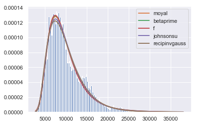

```python
f_TotalSurfaceArea.summary()
```

In contrast to the RMSD data, it seems the Total surface area can be easily approximated by these 5 distributions. However, looking at the (`numpy.random` documentation)[https://www.numpy.org/devdocs/reference/routines.random.html], the only standard method to generate random numbers is through the `numpy.random.f` (F distribution). This is one of the main problems of fitting a curve first and then trying to determine a method to generate random numbers that follows a particular distribution - ITS is much easier.

In any case, for illustrative purposes, random numbers following the distributions below will be generated from parameters given by the `fitted_param` object:

1. Moyal distribution - this is not available from `numpy.random`, so [`scipy.stats.moyal.rvs()`](https://docs.scipy.org/doc/scipy/reference/generated/scipy.stats.moyal.html) will be used
2. F distribution - although the Moyal distribution has the lowest error, the F distribution seems to be similar.

These two distributions will also be compared visually to the one from ITS method.

```python
# for numpy.random, we have to match the scipy parameters from fitted_param into numpy.random arguments
TotalArea_random_F = (np.random.f(f_TotalSurfaceArea.fitted_param['f'][0],
                      f_TotalSurfaceArea.fitted_param['f'][1], len(df)) *
                      f_TotalSurfaceArea.fitted_param['f'][3] ) - f_TotalSurfaceArea.fitted_param['f'][2]

TotalArea_random_moyal = moyal.rvs(f_TotalSurfaceArea.fitted_param['moyal'][0],
                                   f_TotalSurfaceArea.fitted_param['moyal'][1], len(df))

TotalArea_ITS = inverse_transform_sampling(df['Total surface area'], n_samples=len(df))

TotalArea_random_F = TotalArea_random_F.astype(dtype = 'float32', casting = 'same_kind')
TotalArea_random_moyal = TotalArea_random_moyal.astype(dtype = 'float32', casting = 'same_kind')
TotalArea_ITS = TotalArea_ITS.astype(dtype = 'float32', casting = 'same_kind')
```

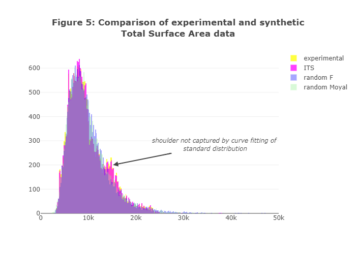

```python
trace_experimental = go.Histogram(x = df['Total surface area'], opacity= 0.75, name = 'experimental',
                                  marker = dict(color = 'yellow'))

trace_ITS = go.Histogram(x = TotalArea_ITS, opacity= 0.75, name = 'ITS',
                                   marker = dict(color = 'magenta'))

trace_random_F = go.Histogram(x = TotalArea_random_F, opacity= 0.35, name = 'random F',
                                   marker = dict(color = 'blue'))

trace_random_moyal = go.Histogram(x = TotalArea_random_moyal, opacity= 0.35, name = 'random Moyal',
                                   marker = dict(color = 'lightgreen'))

data = [trace_experimental, trace_ITS, trace_random_F, trace_random_moyal]

# https://plot.ly/python/text-and-annotations/
# https://plot.ly/python/axes/

layout = go.Layout(barmode = 'overlay',
                   title = '<b>Figure 5: Comparison of experimental and synthetic<br>Total Surface Area data</b>',
                   xaxis=dict(range=[0, 50000]),
    annotations=[
        dict(
            x=15200,
            y=200,
            xref='x',
            yref='y',
            text='<i>shoulder not captured by curve fitting of <br>standard distribution</i>',
            showarrow=True,
            arrowhead=2,
            arrowwidth = 2,
            arrowsize = 1,
            ax=200,
            ay=-40,
            align = 'center'
        )
    ]
)

fig = go.Figure(data=data, layout=layout)
# iplot(fig)
img_bytes = pio.to_image(fig, format='png')
Image(img_bytes)
```

While our random numbers closely mimic the experimental data, it does not fully capture the subtleties present, for instance, the shoulder around (x = 15000, y = 200) (annotated above).

### Non-polar Exposed Area

In this section, we will generate synthetic Non-polar exposed area data.

```python
f_NPEA = Fitter(df['Non-polar exposed area'], bins=200)
f_NPEA.fit()
```

```
Fitted alpha distribution with error=3.678925586942494e-08, AIC=4663.1062066840295, BIC=4687.218294592306)
Fitted anglit distribution with error=1.9843725656404864e-06, AIC=3970.333989305675, BIC=3986.4087145778594)
Fitted arcsine distribution with error=2.7604523721356452e-06, AIC=3906.463651779715, BIC=3922.5383770518993)
```

```
E:\Program Files (x86)\Microsoft Visual Studio\Shared\Python37_64\lib\site-packages\scipy\stats\_continuous_distns.py:6532: RuntimeWarning:

divide by zero encountered in double_scalars
```

```
Fitted argus distribution with error=2.634455052356412e-06, AIC=3858.2608000287955, BIC=3882.372887937072)
Fitted beta distribution with error=5.31345675441063e-08, AIC=5058.101711592413, BIC=5090.251162136782)
Fitted betaprime distribution with error=3.408534650989799e-08, AIC=4633.050190756943, BIC=4665.199641301312)
Fitted bradford distribution with error=1.5432867953848278e-06, AIC=3879.8391690466824, BIC=3903.951256954959)
Fitted burr distribution with error=2.0561322984934345e-07, AIC=4429.375750093599, BIC=4461.525200637968)
```

```
E:\Program Files (x86)\Microsoft Visual Studio\Shared\Python37_64\lib\site-packages\scipy\stats\_continuous_distns.py:768: RuntimeWarning:

overflow encountered in power
```

```
Fitted burr12 distribution with error=2.9464960678852713e-06, AIC=4413.338506251447, BIC=4445.487956795816)
Fitted cauchy distribution with error=2.56810227340771e-07, AIC=4488.833254284032, BIC=4504.907979556216)
Fitted chi distribution with error=1.5653972357363993e-07, AIC=5944.272528483451, BIC=5968.384616391728)
Fitted chi2 distribution with error=5.608856540037681e-08, AIC=5071.180729594946, BIC=5095.292817503222)
Fitted cosine distribution with error=1.7142908180493399e-06, AIC=4125.345562482416, BIC=4141.4202877546)
Fitted crystalball distribution with error=3.121253587917722e-06, AIC=inf, BIC=inf)
Fitted dgamma distribution with error=2.810032740456121e-07, AIC=5297.0572046977895, BIC=5321.169292606066)
Fitted dweibull distribution with error=2.6822687951882724e-07, AIC=5486.157401381136, BIC=5510.269489289412)
```

[output not shown]

[output cut: 2332 more lines]

[output not shown]

```
Fitted erlang distribution with error=2.8535054523074254e-07, AIC=6314.7486648828335, BIC=6338.86075279111)
Fitted expon distribution with error=1.3955479385563948e-06, AIC=4291.21020194811, BIC=4307.284927220294)
Fitted exponnorm distribution with error=2.6311072973365234e-08, AIC=4713.408131274537, BIC=4737.520219182813)
Fitted exponpow distribution with error=3.121253587917722e-06, AIC=inf, BIC=inf)
```

```
E:\Program Files (x86)\Microsoft Visual Studio\Shared\Python37_64\lib\site-packages\scipy\stats\_continuous_distns.py:1380: RuntimeWarning:

invalid value encountered in add
```

```
Fitted exponweib distribution with error=8.466028297712115e-06, AIC=4451.729644255354, BIC=4483.879094799723)
Fitted f distribution with error=3.3862634637220106e-08, AIC=4758.385460395295, BIC=4790.534910939664)
Fitted fatiguelife distribution with error=3.169084769041547e-07, AIC=4328.72081066516, BIC=4352.832898573436)
Fitted fisk distribution with error=3.5763027667451976e-08, AIC=4542.712655659695, BIC=4566.824743567971)
Fitted foldcauchy distribution with error=1.9014027621564046e-07, AIC=4358.25064099478, BIC=4382.362728903056)
Fitted foldnorm distribution with error=3.121253587917722e-06, AIC=inf, BIC=inf)
Fitted frechet_l distribution with error=3.956320364494568e-06, AIC=4952.14625897031, BIC=4976.258346878586)
Fitted frechet_r distribution with error=4.196921792588656e-06, AIC=4930.153832742106, BIC=4954.265920650382)
Fitted gamma distribution with error=5.323134905432527e-08, AIC=5068.497255020249, BIC=5092.609342928526)
```

```
E:\Program Files (x86)\Microsoft Visual Studio\Shared\Python37_64\lib\site-packages\scipy\stats\_continuous_distns.py:3080: RuntimeWarning:

invalid value encountered in power
```

[output not shown]

[output cut: 16 more lines]

```
Fitted semicircular distribution with error=2.186639217063218e-06, AIC=3891.828063299176, BIC=3907.9027885713604)
Fitted skewnorm distribution with error=6.80320185987756e-08, AIC=5562.57020359719, BIC=5586.682291505466)
Fitted t distribution with error=2.656491160784424e-07, AIC=5069.493931329613, BIC=5093.606019237889)
Fitted trapz distribution with error=3.2005194110884827e-06, AIC=3982.9556275141804, BIC=4015.105078058549)
Fitted triang distribution with error=1.2297030896942963e-06, AIC=3971.0161064211306, BIC=3995.128194329407)
Fitted truncexpon distribution with error=1.6778212798295835e-06, AIC=3931.688394128381, BIC=3955.8004820366573)
Fitted truncnorm distribution with error=3.121253587917722e-06, AIC=inf, BIC=inf)
SKIPPED tukeylambda distribution(taking more than 30 seconds)
Fitted uniform distribution with error=2.2214202146750915e-06, AIC=3847.8747196304685, BIC=3863.949444902653)
Fitted vonmises distribution with error=1.2191979227851372e+52, AIC=-22572.580305843665, BIC=-22548.468217935388)
Fitted vonmises_line distribution with error=3.747079677967181e-07, AIC=5775.822025293193, BIC=5799.93411320147)
Fitted wald distribution with error=4.5687043353965747e-07, AIC=4245.270998032939, BIC=4261.345723305123)
Fitted weibull_max distribution with error=3.956320364494568e-06, AIC=4952.14625897031, BIC=4976.258346878586)
Fitted weibull_min distribution with error=4.196921792588656e-06, AIC=4930.153832742106, BIC=4954.265920650382)
Fitted wrapcauchy distribution with error=nan, AIC=nan, BIC=nan)
```

|  | sumsquare_error | AIC | BIC |
| --- | --- | --- | --- |
| exponnorm | 2.631107e-08 | 4713.408131 | 4737.520219 |
| moyal | 2.780875e-08 | 4777.123855 | 4793.198580 |
| invgamma | 3.171191e-08 | 4708.791311 | 4732.903399 |
| genextreme | 3.180476e-08 | 4740.224072 | 4764.336160 |
| johnsonsu | 3.220567e-08 | 4763.138900 | 4795.288351 |

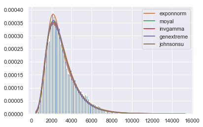

```python
f_NPEA.summary()
```

Similar to the Total Surface Area above, there are more than one distribution function that can adequately describe the Non-polar Exposed Area data. Hence, only the Moyal and exponentially modified Normal (exponnorm) distributions will be used to generate a synthetic data alongside ITS.

```python
# create synthetic data
NonpolarExposedArea_random_moyal = moyal.rvs(f_NPEA.fitted_param['moyal'][0],
                                             f_NPEA.fitted_param['moyal'][1], len(df))

NonpolarExposedArea_random_exponnorm = exponnorm.rvs(f_NPEA.fitted_param['exponnorm'][0],
                                                     f_NPEA.fitted_param['exponnorm'][1],
                                                     f_NPEA.fitted_param['exponnorm'][2], len(df))

NonpolarExposedArea_ITS = inverse_transform_sampling(df['Non-polar exposed area'])

NonpolarExposedArea_random_moyal = NonpolarExposedArea_random_moyal.astype(dtype = 'float32', casting = 'same_kind')
NonpolarExposedArea_random_exponnorm = NonpolarExposedArea_random_exponnorm.astype(
                                    dtype = 'float32', casting = 'same_kind')
NonpolarExposedArea_ITS = NonpolarExposedArea_ITS.astype(dtype = 'float32', casting = 'same_kind')
```

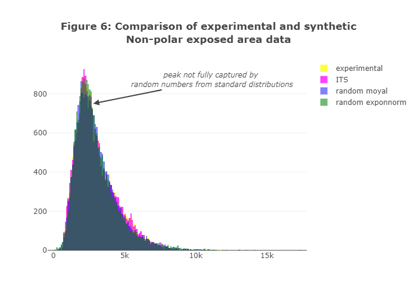

```python
# plot original and synthetic data

trace_experimental = go.Histogram(x = df['Non-polar exposed area'], opacity= 0.75, name = 'experimental',
                                  marker = dict(color = 'yellow'))
trace_ITS = go.Histogram(x = NonpolarExposedArea_ITS, opacity= 0.75, name = 'ITS',
                                   marker = dict(color = 'magenta'))

trace_random1 = go.Histogram(x = NonpolarExposedArea_random_moyal, opacity= 0.5, name = 'random moyal',
                                   marker = dict(color = 'blue'))

trace_random2 = go.Histogram(x = NonpolarExposedArea_random_exponnorm, opacity= 0.55, name = 'random exponnorm',
                                   marker = dict(color = 'green'))

data = [trace_experimental, trace_ITS, trace_random1, trace_random2]

layout = go.Layout(barmode = 'overlay',
                   title = '<b>Figure 6: Comparison of experimental and synthetic<br>Non-polar exposed area data</b>',
    annotations=[
        dict(
            x=2800,
            y=750,
            xref='x',
            yref='y',
            text='<i>peak not fully captured by <br>random numbers from standard distributions</i>',
            showarrow=True,
            arrowhead=2,
            arrowwidth = 2,
            arrowsize = 1,
            ax=200,
            ay=-40,
            align = 'center'
        )
    ]
)

fig = go.Figure(data=data, layout=layout)
# iplot(fig)

img_bytes = pio.to_image(fig, format='png')
Image(img_bytes)
```

From Figure 6, we can conclude that the ITS and standard distributions result in relatively similar curves, although there are very minor differences from the experimental data.

### Fractional area of exposed non polar residue

For this data, we will continue to employ the same strategy as for the previous variables.

```python
f_FAENPR = Fitter(df['Fractional area of exposed non-polar residue'], bins=200)
f_FAENPR.fit()
```

```
Fitted alpha distribution with error=8.093314934614217, AIC=245.41622324479033, BIC=269.5283111530668)
Fitted anglit distribution with error=518.0423459221691, AIC=-190.37863224910183, BIC=-174.30390697691752)
Fitted arcsine distribution with error=1975.9698967266681, AIC=-226.6751043467027, BIC=-210.6003790745184)
Fitted argus distribution with error=1095.160141472109, AIC=-383.549129428025, BIC=-359.43704151974856)
```

[output not shown]

[output not shown]

[output not shown]

[output cut: 672 more lines]

[output not shown]

[output not shown]

[output cut: 27 more lines]

[output not shown]

|  | sumsquare_error | AIC | BIC |
| --- | --- | --- | --- |
| johnsonsu | 7.806415 | 248.290351 | 280.439802 |
| nct | 7.813336 | 241.540548 | 273.689998 |
| f | 7.832769 | 254.900301 | 287.049752 |
| norminvgauss | 7.834372 | 234.088729 | 266.238180 |
| betaprime | 7.834545 | 255.196096 | 287.345547 |

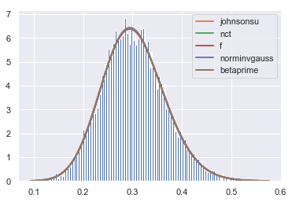

```python
f_FAENPR.summary()
```

Given the shape and error, the [Johnson SU (unbounded support)](https://www.rdocumentation.org/packages/ExtDist/versions/0.6-3/topics/JohnsonSU) distribution is the best fit. In addition, there are no atypical 'features' such as a peak shoulder that needs to be included. Interestingly, the shape of the histogram looks like a normal distribution, but somehow this is not showing up in the fit summary, perhaps due a slightly larger error than a pure Johnson SU. For completeness, we will include a normal distribution as well in the comparison plot.

```python
# create synthetic data

FractionalAreaExposedNonPolarResidue_random_johnsonsu = johnsonsu.rvs(f_FAENPR.fitted_param['johnsonsu'][0],
                                                                      f_FAENPR.fitted_param['johnsonsu'][1],
                                                                      f_FAENPR.fitted_param['johnsonsu'][2],
                                                                      f_FAENPR.fitted_param['johnsonsu'][3], len(df))

FractionalAreaExposedNonPolarResiduea_random_norm = norm.rvs(f_FAENPR.fitted_param['norm'][0],
                                                     f_FAENPR.fitted_param['norm'][1], len(df))

FractionalAreaExposedNonPolarResidue_ITS = inverse_transform_sampling(df['Fractional area of exposed non-polar residue'])

FractionalAreaExposedNonPolarResidue_random_johnsonsu = FractionalAreaExposedNonPolarResidue_random_johnsonsu.astype(
                                    dtype = 'float32', casting = 'same_kind')
FractionalAreaExposedNonPolarResiduea_random_norm = FractionalAreaExposedNonPolarResiduea_random_norm.astype(
                                    dtype = 'float32', casting = 'same_kind')
FractionalAreaExposedNonPolarResidue_ITS = FractionalAreaExposedNonPolarResidue_ITS.astype(
                                    dtype = 'float32', casting = 'same_kind')
```

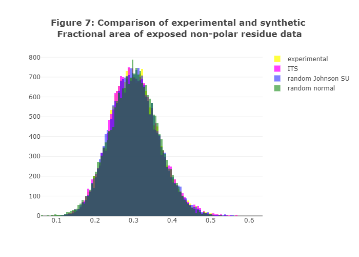

```python
# plot original and synthetic data

trace_experimental = go.Histogram(x = df['Fractional area of exposed non-polar residue'], opacity= 0.75,
                                  name = 'experimental',
                                  marker = dict(color = 'yellow'))

trace_ITS = go.Histogram(x = FractionalAreaExposedNonPolarResidue_ITS, opacity= 0.75, name = 'ITS',
                                   marker = dict(color = 'magenta'))

trace_random1 = go.Histogram(x = FractionalAreaExposedNonPolarResidue_random_johnsonsu, opacity= 0.5,
                                   name = 'random Johnson SU',
                                   marker = dict(color = 'blue'))

trace_random2 = go.Histogram(x = FractionalAreaExposedNonPolarResiduea_random_norm, opacity= 0.55,
                                   name = 'random normal',
                                   marker = dict(color = 'green'))

data = [trace_experimental, trace_ITS, trace_random1, trace_random2]

layout = go.Layout(barmode = 'overlay',
                   title = '<b>Figure 7: Comparison of experimental and synthetic <br>' +
                   'Fractional area of exposed non-polar residue data</b>')

fig = go.Figure(data=data, layout=layout)
# iplot(fig)
img_bytes = pio.to_image(fig, format='png')
Image(img_bytes)
```

Figure 7 above shows that indeed, a normal distribution is just as good as Johnson SU. As normality is assumed in many parametric statistical tests, and as non-parametric ones are less powerful, the ability to fit a normal distribution can be considered crucial so long as no information is lost.

### Fractional area of exposed non polar part of residue

In this section, we will look at Fractional area of exposed non polar part of residue, which is related but is not the same as Fractional area of exposed non-polar residue data.

```python
f_FAENPRR = Fitter(df['Fractional area of exposed non-polar part of residue'], bins=200)
f_FAENPRR.fit()
```

[output not shown]

[output not shown]

[output cut: 880 more lines]

[output not shown]

[output not shown]

[output cut: 20 more lines]

[output not shown]

[output not shown]

|  | sumsquare_error | AIC | BIC |
| --- | --- | --- | --- |
| exponnorm | 0.000194 | 2752.687091 | 2776.799179 |
| burr | 0.000220 | 2755.106751 | 2787.256202 |
| mielke | 0.000220 | 2755.112937 | 2787.262388 |
| johnsonsu | 0.000229 | 2793.751838 | 2825.901289 |
| invgamma | 0.000230 | 2776.919997 | 2801.032085 |

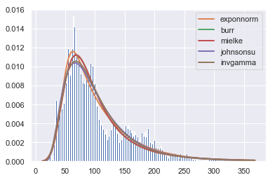

```python
f_FAENPRR.summary()
```

This data is a bit complicated to model adequately with the presence of several minor peaks. While this is another example where ITS will be quite useful, it is also possible that these are outliers (see Figure 1).

As the exponentially-modified normal distribution (exponnorm) has the lowest error, this will be used to generate the synthetic dataset along with ITS.

```python
# create synthetic data

FractionalAreaExposedNonPolarPartOfResidue_random_exponnorm = exponnorm.rvs(f_FAENPRR.fitted_param['exponnorm'][0],
                                                                      f_FAENPRR.fitted_param['exponnorm'][1],
                                                                      f_FAENPRR.fitted_param['exponnorm'][2], len(df))

FractionalAreaExposedNonPolarPartOfResidue_ITS = inverse_transform_sampling(
                                                    df['Fractional area of exposed non-polar part of residue'])

FractionalAreaExposedNonPolarPartOfResidue_random_exponnorm = FractionalAreaExposedNonPolarPartOfResidue_random_exponnorm.astype(
                                    dtype = 'float32', casting = 'same_kind')

FractionalAreaExposedNonPolarPartOfResidue_ITS = FractionalAreaExposedNonPolarPartOfResidue_ITS.astype(
                                    dtype = 'float32', casting = 'same_kind')
```

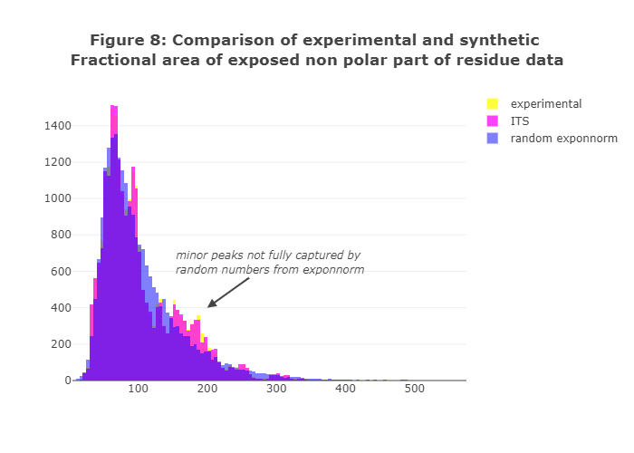

```python
# plot original and synthetic data

trace_experimental = go.Histogram(x = df['Fractional area of exposed non-polar part of residue'], opacity= 0.75,
                                  name = 'experimental',
                                  marker = dict(color = 'yellow'))

trace_ITS = go.Histogram(x = FractionalAreaExposedNonPolarPartOfResidue_ITS, opacity= 0.75,
                                  name = 'ITS',
                                  marker = dict(color = 'magenta'))

trace_random1 = go.Histogram(x = FractionalAreaExposedNonPolarPartOfResidue_random_exponnorm, opacity= 0.5,
                                  name = 'random exponnorm',
                                  marker = dict(color = 'blue'))

data = [trace_experimental, trace_ITS, trace_random1]

layout = go.Layout(barmode = 'overlay', title = '<b>Figure 8: Comparison of experimental and synthetic <br>' +
                   'Fractional area of exposed non polar part of residue data</b>',
    annotations=[
        dict(
            x=200,
            y=400,
            xref='x',
            yref='y',
            text='<i>minor peaks not fully captured by <br>random numbers from exponnorm</i>',
            showarrow=True,
            arrowhead=2,
            arrowwidth = 2,
            arrowsize = 1,
            ax=70,
            ay=-50,
            align = 'center'
        )
    ]
)

fig = go.Figure(data=data, layout=layout)
# iplot(fig)
img_bytes = pio.to_image(fig, format='png')
Image(img_bytes)
```

Again, we see that the random numbers from exponnorm distribution does not fully capture the subtle nuances of the data, especially the minor peaks at around $x$ = 200 and the split main peak at around $x$ = 60 and 90. While it could be that some of these are outliers, we cannot be entirely certain of this.

### Molecular mass weighted exposed area

Let's now look at the molecular mass weighted exposed area. As before, we will try automatic fitting with Fitter first.

```python
f_MMWEA = Fitter(df['Molecular mass weighted exposed area'], bins=200)
f_MMWEA.fit()
```

[output not shown]

[output not shown]

[output cut: 2096 more lines]

[output not shown]

[output not shown]

[output cut: 9 more lines]

[output not shown]

[output not shown]

[output not shown]

|  | sumsquare_error | AIC | BIC |
| --- | --- | --- | --- |
| moyal | 4.188684e-13 | 6806.255648 | 6822.330374 |
| exponweib | 4.263766e-13 | 6729.508942 | 6761.658393 |
| johnsonsu | 4.277906e-13 | 6807.157170 | 6839.306621 |
| johnsonsb | 4.354434e-13 | 7063.120756 | 7095.270206 |
| f | 4.425239e-13 | 6746.007322 | 6778.156772 |

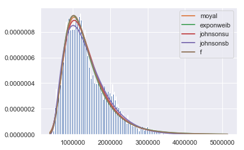

```python
f_MMWEA.summary()
```

As the Moyal distribution results in a very good fit, it will be used to generate a set of random numbers. For comparison, ITS will also be used.

```python
MolecularMassWeightedExposedArea_random_moyal = moyal.rvs(f_MMWEA.fitted_param['moyal'][0],
                                                          f_MMWEA.fitted_param['moyal'][1], len(df))

MolecularMassWeightedExposedArea_ITS = inverse_transform_sampling(
                                                    df['Molecular mass weighted exposed area'])

MolecularMassWeightedExposedArea_random_moyal = MolecularMassWeightedExposedArea_random_moyal.astype(
                                    dtype = 'float32', casting = 'same_kind')

MolecularMassWeightedExposedArea_ITS = MolecularMassWeightedExposedArea_ITS.astype(
                                    dtype = 'float32', casting = 'same_kind')
```

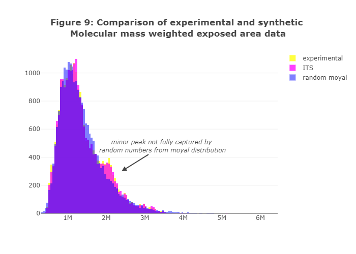

```python
# plot original and synthetic data

trace_experimental = go.Histogram(x = df['Molecular mass weighted exposed area'], opacity= 0.75,
                                  name = 'experimental',
                                  marker = dict(color = 'yellow'))

trace_synthetic = go.Histogram(x = MolecularMassWeightedExposedArea_ITS, opacity= 0.75,
                                  name = 'ITS',
                                  marker = dict(color = 'magenta'))

trace_random1 = go.Histogram(x = MolecularMassWeightedExposedArea_random_moyal, opacity= 0.5,
                                  name = 'random moyal',
                                  marker = dict(color = 'blue'))

data = [trace_experimental, trace_synthetic, trace_random1]

# https://plot.ly/python/text-and-annotations/

layout = go.Layout(barmode = 'overlay',
                   title = '<b>Figure 9: Comparison of experimental and synthetic <br>' +
                   'Molecular mass weighted exposed area data</b>',
    annotations=[
        dict(
            x=2.4e+6,
            y=300,
            xref='x',
            yref='y',
            text='<i>minor peak not fully captured by <br>random numbers from moyal distribution</i>',
            showarrow=True,
            arrowhead=2,
            arrowwidth = 2,
            arrowsize = 1,
            ax=80,
            ay=-50,
            align = 'center'
        )
    ]
)

fig = go.Figure(data=data, layout=layout)
# iplot(fig)

img_bytes = pio.to_image(fig, format='png')
Image(img_bytes)
```

Again, we can see that the Moyal distribution slightly 'simplifies' the actual distribution of the data unlike ITS.

### Average deviation from standard exposed area of residue

In this section, we will look at the Average deviation from standard exposed area of residue.

```python
f_ADSEAR = Fitter(df['Average deviation from standard exposed area of residue'], bins=200)
f_ADSEAR.fit()
```

[output not shown]

[output not shown]

[output cut: 548 more lines]

[output not shown]

[output not shown]

[output cut: 27 more lines]

[output not shown]

|  | sumsquare_error | AIC | BIC |
| --- | --- | --- | --- |
| exponnorm | 0.000028 | 3105.011384 | 3129.123472 |
| johnsonsu | 0.000039 | 3127.787760 | 3159.937210 |
| lognorm | 0.000039 | 3127.029450 | 3151.141537 |
| fatiguelife | 0.000040 | 3168.904271 | 3193.016359 |
| burr | 0.000040 | 3048.149256 | 3080.298706 |

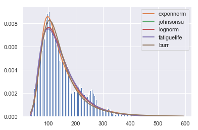

```python
f_ADSEAR.summary()
```

From the Fitter summary above, exponentially-modified normal distribution provides a good description of the data. As such, we can use the automatic fitting parameters to generate random values and compared with ITS and the experimental data.

```python
# create synthetic data - inverse_transform_sampling(data, n_bins=200, n_samples=40000)

AverageDeviationFromStandardExposedAreaOfResidue_random_exponnorm = exponnorm.rvs(
                                                                    f_ADSEAR.fitted_param['exponnorm'][0],
                                                                    f_ADSEAR.fitted_param['exponnorm'][1],
                                                                    f_ADSEAR.fitted_param['exponnorm'][2],
                                                                    len(df))

AverageDeviationFromStandardExposedAreaOfResidue_ITS = inverse_transform_sampling(
                                                    df['Average deviation from standard exposed area of residue'],
                                                    n_samples = len(df))

AverageDeviationFromStandardExposedAreaOfResidue_random_exponnorm = AverageDeviationFromStandardExposedAreaOfResidue_random_exponnorm.astype(
                                    dtype = 'float32', casting = 'same_kind')

AverageDeviationFromStandardExposedAreaOfResidue_ITS = AverageDeviationFromStandardExposedAreaOfResidue_ITS.astype(
                                    dtype = 'float32', casting = 'same_kind')
```

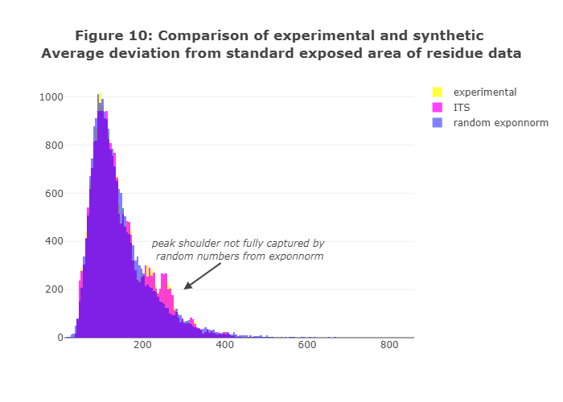

```python
# plot original and synthetic data

trace_experimental = go.Histogram(x = df['Average deviation from standard exposed area of residue'], opacity= 0.75,
                                  name = 'experimental',
                                  marker = dict(color = 'yellow'))

trace_ITS = go.Histogram(x = AverageDeviationFromStandardExposedAreaOfResidue_ITS, opacity= 0.75,
                                  name = 'ITS',
                                  marker = dict(color = 'magenta'))

trace_random1 = go.Histogram(x = AverageDeviationFromStandardExposedAreaOfResidue_random_exponnorm, opacity= 0.5,
                                  name = 'random exponnorm',
                                  marker = dict(color = 'blue'))

data = [trace_experimental, trace_ITS, trace_random1]

layout = go.Layout(barmode = 'overlay',
                   title = '<b>Figure 10: Comparison of experimental and synthetic <br>' +
                   'Average deviation from standard exposed area of residue data</b>',
    annotations=[
        dict(
            x=300,
            y=200,
            xref='x',
            yref='y',
            text='<i>peak shoulder not fully captured by <br>random numbers from exponnorm</i>',
            showarrow=True,
            arrowhead=2,
            arrowwidth = 2,
            arrowsize = 1,
            ax=70,
            ay=-50,
            align = 'center'
        )
    ]
)

fig = go.Figure(data=data, layout=layout)
# iplot(fig)
img_bytes = pio.to_image(fig, format='png')
Image(img_bytes)
```

With the exception of a shoulder at around $x = 250$ and extreme values at the higher end of $x$, both ITS and the exponentially-modified normal distribution capture the full experimental data.

### Euclidian distance

Euclidian distance refers to the [straight-line distance between two points in Euclidean space](https://en.wikipedia.org/wiki/Euclidean_distance). As protein molecules do not follow a regular space, residue depth cannot be calculated easily. Instead, it can be [simplified by several methods including Euclidian distance transform](https://www.ncbi.nlm.nih.gov/pmc/articles/PMC4098708/).

```python
f_EucD = Fitter(df['Euclidian distance'], bins=200)
f_EucD.fit()
```

[output not shown]

```
Fitted alpha distribution with error=1.2675926580739996e-08, AIC=10211.70149104891, BIC=10235.813578957188)
Fitted anglit distribution with error=6.150634743776235e-07, AIC=inf, BIC=inf)
Fitted arcsine distribution with error=6.443535154680564e-07, AIC=4538.425426225633, BIC=4554.500151497817)
```

[output not shown]

```
Fitted argus distribution with error=7.34998827781212e-07, AIC=4472.483959774107, BIC=4496.596047682383)
Fitted beta distribution with error=2.2099791866425782e-08, AIC=25042.083328578297, BIC=25074.232779122667)
```

[output not shown]

```
Fitted betaprime distribution with error=1.8305695616647037e-08, AIC=12501.949967421766, BIC=12534.099417966134)
Fitted bradford distribution with error=6.133189311005922e-07, AIC=4518.762721325921, BIC=4542.8748092341975)
Fitted burr distribution with error=2.488087930437583e-08, AIC=7647.47206572402, BIC=7679.621516268388)
```

[output not shown]

```
Fitted burr12 distribution with error=5.741365254986199e-07, AIC=5230.905591976658, BIC=5263.055042521027)
Fitted cauchy distribution with error=5.942680263291941e-08, AIC=5912.4099462796075, BIC=5928.4846715517915)
Fitted chi distribution with error=7.25554065760061e-07, AIC=inf, BIC=inf)
Fitted chi2 distribution with error=7.255540593855281e-07, AIC=3060717.334101947, BIC=3060741.446189855)
Fitted cosine distribution with error=6.170724027323735e-07, AIC=inf, BIC=inf)
```

[output not shown]

```
Fitted crystalball distribution with error=7.25554065760061e-07, AIC=inf, BIC=inf)
Fitted dgamma distribution with error=2.0402754979030203e-08, AIC=19280.235714832106, BIC=19304.347802740383)
Fitted dweibull distribution with error=2.9763195587702735e-08, AIC=18792.31895473224, BIC=18816.431042640517)
```

[output not shown]

[output cut: 2276 more lines]

[output not shown]

```
Fitted erlang distribution with error=2.3584273208416777e-08, AIC=24465.328338940024, BIC=24489.4404268483)
Fitted expon distribution with error=4.3124063356245683e-07, AIC=8192.291247915382, BIC=8208.365973187565)
Fitted exponnorm distribution with error=7.116860416099453e-09, AIC=16701.48126599565, BIC=16725.59335390393)
```

[output not shown]

```
Fitted exponpow distribution with error=7.25554065760061e-07, AIC=inf, BIC=inf)
```

[output not shown]

[output not shown]

[output not shown]

[output not shown]

[output not shown]

[output not shown]

[output not shown]

```
SKIPPED ksone distribution(taking more than 30 seconds)
Fitted kstwobign distribution with error=9.235125156506661e-08, AIC=nan, BIC=nan)
Fitted laplace distribution with error=3.987423998874584e-08, AIC=17354.87895226437, BIC=17370.953677536556)
Fitted levy distribution with error=4.1626069173774194e-07, AIC=4992.98707355397, BIC=5009.061798826154)
Fitted levy_l distribution with error=7.111937781583881e-07, AIC=5299.884341967803, BIC=5315.959067239987)
SKIPPED levy_stable distribution(taking more than 30 seconds)
Fitted loggamma distribution with error=2.011756198045891e-07, AIC=86284.70250058128, BIC=86308.81458848955)
Fitted logistic distribution with error=1.0372400031460902e-08, AIC=22597.232557604584, BIC=22613.30728287677)
```

[output not shown]

```
Fitted loglaplace distribution with error=4.281024444992251e-08, AIC=7280.720443481829, BIC=7304.832531390105)
Fitted lognorm distribution with error=7.921788424021688e-07, AIC=5394.039455207281, BIC=5418.151543115558)
Fitted lomax distribution with error=3.831576107782904e-07, AIC=7429.93030680248, BIC=7454.0423947107565)
Fitted maxwell distribution with error=5.2991000963507906e-08, AIC=77035.39920793312, BIC=77051.4739332053)
```

[output not shown]

```
Fitted mielke distribution with error=3.6536638371099533e-07, AIC=5127.721096860297, BIC=5159.870547404666)
Fitted moyal distribution with error=4.88620259340702e-08, AIC=12494.211269695988, BIC=12510.285994968173)
Fitted nakagami distribution with error=6.618969151352352e-08, AIC=68442.86669982973, BIC=68466.978787738)
SKIPPED ncf distribution(taking more than 30 seconds)
```

[output not shown]

[output not shown]

[output not shown]

[output not shown]

[output not shown]

[output not shown]

[output not shown]

|  | sumsquare_error | AIC | BIC |
| --- | --- | --- | --- |
| genlogistic | 6.372235e-09 | 18380.447561 | 18404.559649 |
| fisk | 7.042833e-09 | 9019.137374 | 9043.249461 |
| exponnorm | 7.116860e-09 | 16701.481266 | 16725.593354 |
| johnsonsu | 8.957774e-09 | 9609.400776 | 9641.550227 |
| logistic | 1.037240e-08 | 22597.232558 | 22613.307283 |

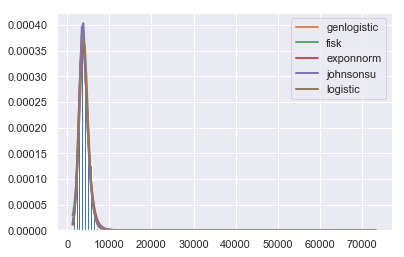

```python
f_EucD.summary()
```

As there are several distributions with good fits to the experimental data, we will use the Fisk distribution as it has the lowest AIC/BIC with only a marginally higher error compared to the other distributions.

```python
# create synthetic data

EuclidianDistance_random_fisk = fisk.rvs(f_EucD.fitted_param['fisk'][0],
                                   f_EucD.fitted_param['fisk'][1], f_EucD.fitted_param['fisk'][2],
                                                       len(df))

EuclidianDistance_ITS = inverse_transform_sampling(df['Euclidian distance'], n_samples=len(df))

EuclidianDistance_random_fisk = EuclidianDistance_random_fisk.astype(
                                    dtype = 'float32', casting = 'same_kind')

EuclidianDistance_ITS = EuclidianDistance_ITS.astype(
                                    dtype = 'float32', casting = 'same_kind')
```

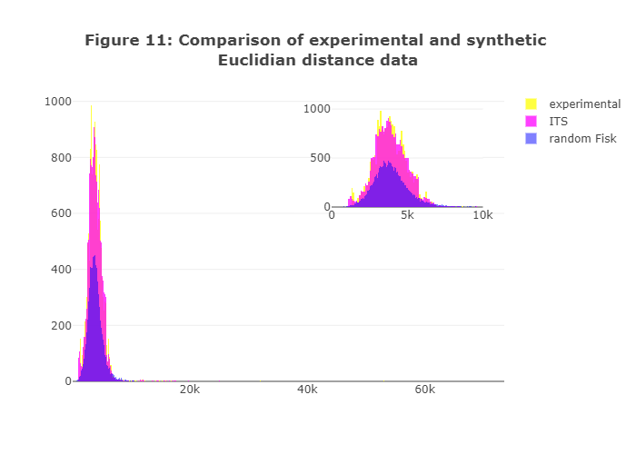

```python
# plot original and synthetic data
# for inset: https://plot.ly/python/insets/
# we use showlegend=False for the inset traces to hide them from the legend, otherwise we'll be seeing double entries
# https://plot.ly/python/legend/#hide-legend-entries

trace_experimental = go.Histogram(x = df['Euclidian distance'], opacity= 0.75,
                                  name = 'experimental',
                                  marker = dict(color = 'yellow'))

trace_ITS = go.Histogram(x = EuclidianDistance_ITS, opacity= 0.75,
                                  name = 'ITS',
                                  marker = dict(color = 'magenta'))

trace_random1 = go.Histogram(x = EuclidianDistance_random_fisk, opacity= 0.5,
                                  name = 'random Fisk',
                                  marker = dict(color = 'blue'))

trace_experimental_inset = go.Histogram(x = df['Euclidian distance'], opacity= 0.75,
                                  name = 'experimental', showlegend = False,
                                  marker = dict(color = 'yellow'), xaxis = 'x2', yaxis='y2')

trace_ITS_inset = go.Histogram(x = EuclidianDistance_ITS, opacity= 0.75,
                                  name = 'synthetic by ITS', showlegend = False,
                                  marker = dict(color = 'magenta'), xaxis = 'x2', yaxis='y2')

trace_random1_inset = go.Histogram(x = EuclidianDistance_random_fisk, opacity= 0.5,
                                  name = 'random Fisk', showlegend = False,
                                  marker = dict(color = 'blue'), xaxis = 'x2', yaxis='y2')

data = [trace_experimental, trace_ITS, trace_random1,
        trace_experimental_inset, trace_ITS_inset, trace_random1_inset]

# https://plot.ly/python/text-and-annotations/

layout = go.Layout(barmode = 'overlay',
                   title = '<b>Figure 11: Comparison of experimental and synthetic <br>' +
                   'Euclidian distance data</b>',

    xaxis2 = dict(domain = [0.6, 0.95], anchor = 'y2', range = [0,10000]),
    yaxis2 = dict(domain = [0.6, 0.95], anchor = 'x2')
)

fig = go.Figure(data=data, layout=layout)
# iplot(fig)
img_bytes = pio.to_image(fig, format='png')
Image(img_bytes)
```

For the plot above, an inset plot focused around the mode of the distribution was created to provide a better visual for comparative purposes, as there are extreme $x$ values with very low counts. This is also apparent from the box plots (Figure 1) where the number of outliers are much higher than that for the other variables. Perhaps due to this, the peak from the Fisk distribution does not entirely reach the same height ($y$ value) as the experimental and ITS traces.

### Secondary structure penalty

We will now look at the secondary structure penalty, a measure [often used in protein sequence alignment and structure prediction](https://www.ncbi.nlm.nih.gov/pubmed/25524475).

```python
f_SSP = Fitter(df['Secondary structure penalty'], bins=200)
f_SSP.fit()
```

[output not shown]

```
Fitted alpha distribution with error=0.04464622997672264, AIC=3560.934463191752, BIC=3585.0465511000284)
Fitted anglit distribution with error=0.002543502458486693, AIC=2467.560109778178, BIC=2483.634835050362)
```

[output not shown]

```
Fitted arcsine distribution with error=0.003588788140973162, AIC=2405.7592825693164, BIC=2421.834007841501)
```

[output not shown]

```
Fitted argus distribution with error=0.003844236171999918, AIC=2290.667732544917, BIC=2314.779820453193)
Fitted beta distribution with error=0.0004515588074433137, AIC=2874.0722284513904, BIC=2906.2216789957592)
```

[output not shown]

```
Fitted betaprime distribution with error=0.0003187904697997799, AIC=2770.9360273046523, BIC=2803.085477849021)
Fitted bradford distribution with error=0.001493763384540603, AIC=2445.505065013162, BIC=2469.6171529214384)
Fitted burr distribution with error=0.00032775430062092256, AIC=2794.5548264567174, BIC=2826.7042770010858)
```

[output not shown]

```
Fitted burr12 distribution with error=0.0010391440287315073, AIC=2713.585323892028, BIC=2745.734774436397)
Fitted cauchy distribution with error=0.0007466123769649962, AIC=2903.6597239770654, BIC=2919.73444924925)
Fitted chi distribution with error=0.0006173924880447689, AIC=2941.3609935727527, BIC=2965.473081481029)
Fitted chi2 distribution with error=0.0003547772890838453, AIC=2835.21239288759, BIC=2859.3244807958663)
Fitted cosine distribution with error=0.00216559256718824, AIC=2619.4959594339252, BIC=2635.5706847061097)
```

[output not shown]

```
Fitted crystalball distribution with error=0.0011649360844200106, AIC=3311.244714925716, BIC=3343.3941654700848)
Fitted dgamma distribution with error=0.0007232217615525091, AIC=3091.0708732786297, BIC=3115.182961186906)
Fitted dweibull distribution with error=0.0007679071711770963, AIC=3074.5356017372383, BIC=3098.6476896455147)
```

[output not shown]

[output cut: 2316 more lines]

[output not shown]

[output not shown]

[output not shown]

[output not shown]

[output not shown]

[output not shown]

```
E:\Program Files (x86)\Microsoft Visual Studio\Shared\Python37_64\lib\site-packages\scipy\stats\_continuous_distns.py:3785: RuntimeWarning:

divide by zero encountered in true_divide
```

```
Fitted loglaplace distribution with error=0.024106257529894034, AIC=3198.1664487920157, BIC=3222.278536700292)
Fitted lognorm distribution with error=0.0003064786300392661, AIC=2786.382873013691, BIC=2810.4949609219675)
Fitted lomax distribution with error=0.013579480622170967, AIC=2938.126034176381, BIC=2962.2381220846573)
Fitted maxwell distribution with error=0.0009044007219934781, AIC=3199.203015620209, BIC=3215.2777408923935)
```

[output not shown]

[output not shown]

[output not shown]

```
Fitted powerlognorm distribution with error=0.00030896264231406015, AIC=2801.7634712596696, BIC=2833.912921804038)
```

[output not shown]

```
Fitted powernorm distribution with error=nan, AIC=3162.564863603529, BIC=3186.6769515118053)
Fitted rayleigh distribution with error=0.0008230363822755095, AIC=3160.469951451144, BIC=3176.5446767233284)
Fitted rdist distribution with error=0.0011678409324094477, AIC=3305.9929532178426, BIC=3330.105041126119)
```

[output not shown]

[output not shown]

[output not shown]

```
Fitted truncnorm distribution with error=0.9262756882385936, AIC=inf, BIC=inf)
```

[output not shown]

[output not shown]

[output not shown]

|  | sumsquare_error | AIC | BIC |
| --- | --- | --- | --- |
| lognorm | 0.000306 | 2786.382873 | 2810.494961 |
| johnsonsu | 0.000306 | 2788.241585 | 2820.391035 |
| invgauss | 0.000307 | 2787.562199 | 2811.674286 |
| exponweib | 0.000307 | 2785.527918 | 2817.677368 |
| powerlognorm | 0.000309 | 2801.763471 | 2833.912922 |

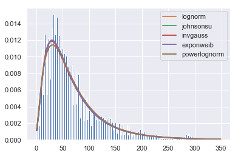

```python
f_SSP.summary()
```

For this case, several distributions have very similar error, AIC and BIC values. Visually, they all seem to overlap with each other and it is not entirely clear if any one distribution has an advantage over the others. Therefore, by random choice, the inverse Gaussian (invgauss) will be used.

```python
# create synthetic data

SecondaryStructurePenalty_random_invgauss = invgauss.rvs(f_SSP.fitted_param['invgauss'][0],
                                                                      f_SSP.fitted_param['invgauss'][1],
                                                                      f_SSP.fitted_param['invgauss'][2], len(df))

SecondaryStructurePenalty_ITS = inverse_transform_sampling(df['Secondary structure penalty'])

SecondaryStructurePenalty_random_invgauss = SecondaryStructurePenalty_random_invgauss.astype(
                                    dtype = 'float32', casting = 'same_kind')

SecondaryStructurePenalty_ITS = SecondaryStructurePenalty_ITS.astype(
                                    dtype = 'float32', casting = 'same_kind')
```

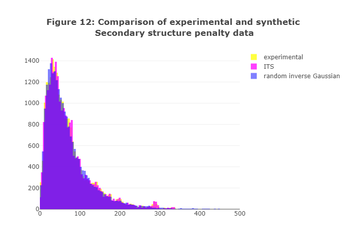

```python
trace_experimental = go.Histogram(x = df['Secondary structure penalty'], opacity= 0.75,
                                  name = 'experimental',
                                  marker = dict(color = 'yellow'))

trace_ITS = go.Histogram(x = SecondaryStructurePenalty_ITS, opacity= 0.75,
                                  name = 'ITS',
                                  marker = dict(color = 'magenta'))

trace_random1 = go.Histogram(x = SecondaryStructurePenalty_random_invgauss, opacity= 0.5,
                                  name = 'random inverse Gaussian',
                                  marker = dict(color = 'blue'))

data = [trace_experimental, trace_ITS, trace_random1]

# the maximum x value in the experimental data is 350 but invgauss.rvs returned data up to about 600
# therefore, we will rescale the plot on xaxis
layout = go.Layout(barmode = 'overlay',
                   title = '<b>Figure 12: Comparison of experimental and synthetic <br>' +
                   'Secondary structure penalty data</b>',
                   xaxis=dict(range=[0, 500]))

fig = go.Figure(data=data, layout=layout)
# iplot(fig)
img_bytes = pio.to_image(fig, format='png')
Image(img_bytes)
```

For this variable, it seems the inverse Gaussian (chosen randomly) is almost as good as ITS in generating random values matching the experimental distribution. This could be caused by the absence of outliers (see Figure 1).

### Spatial distribution constraints

This variable is another penalty-type value used in enhancing the prediction accuracy of protein structures, although it could [lead to local energy minima and poor sampling efficiency in structure simulations](https://www.ncbi.nlm.nih.gov/pubmed/16267688).

```python
f_SDCons = Fitter(df['Spatial Distribution constraints (N,K Value)'], bins=200)
f_SDCons.fit()
```

```
E:\Program Files (x86)\Microsoft Visual Studio\Shared\Python37_64\lib\site-packages\scipy\stats\_distn_infrastructure.py:2305: RuntimeWarning:

invalid value encountered in double_scalars
```

```
Fitted alpha distribution with error=0.0355602015917608, AIC=1653.480936848545, BIC=1677.5930247568215)
Fitted anglit distribution with error=0.06221774573021478, AIC=1463.761377382549, BIC=1479.8361026547332)
```

```
E:\Program Files (x86)\Microsoft Visual Studio\Shared\Python37_64\lib\site-packages\scipy\stats\_continuous_distns.py:312: RuntimeWarning:

divide by zero encountered in true_divide
```

```
Fitted arcsine distribution with error=0.23568917954697507, AIC=1501.8600178462173, BIC=1517.9347431184015)
Fitted argus distribution with error=0.047696071054057286, AIC=1476.619958018383, BIC=1500.7320459266593)
Fitted beta distribution with error=0.018884884569063086, AIC=1599.8353719019328, BIC=1631.9848224463015)
```

[output not shown]

[output not shown]

```
E:\Program Files (x86)\Microsoft Visual Studio\Shared\Python37_64\lib\site-packages\scipy\stats\_distn_infrastructure.py:1615: RuntimeWarning:

divide by zero encountered in log
```

```
Fitted crystalball distribution with error=0.02785895152250028, AIC=1632.070269258002, BIC=1664.2197198023707)
Fitted dgamma distribution with error=0.026561963494166813, AIC=1632.2896867038294, BIC=1656.4017746121058)
Fitted dweibull distribution with error=0.0337794255891393, AIC=1620.6187370907478, BIC=1644.7308249990242)
```

[output not shown]

[output cut: 2336 more lines]

[output not shown]

[output not shown]

```
E:\Program Files (x86)\Microsoft Visual Studio\Shared\Python37_64\lib\site-packages\scipy\stats\_continuous_distns.py:3080: RuntimeWarning:

divide by zero encountered in power
```

```
Fitted gausshyper distribution with error=0.11634727273586078, AIC=1417.2854159013048, BIC=1465.5095917178578)
Fitted genexpon distribution with error=0.17290947148656494, AIC=1462.1722195597526, BIC=1502.3590327402135)
```

```
E:\Program Files (x86)\Microsoft Visual Studio\Shared\Python37_64\lib\site-packages\scipy\stats\_continuous_distns.py:2276: RuntimeWarning:

invalid value encountered in subtract
```

```
Fitted genextreme distribution with error=1.5134323772320695, AIC=2338.580803282375, BIC=2362.6928911906516)
Fitted gengamma distribution with error=0.03704043446124279, AIC=1598.5031301557215, BIC=1630.65258070009)
Fitted genhalflogistic distribution with error=0.09329001232696904, AIC=1408.826645954011, BIC=1432.9387338622873)
Fitted genlogistic distribution with error=0.018133808151300765, AIC=1592.6892908076743, BIC=1616.8013787159507)
Fitted gennorm distribution with error=0.030012672811856787, AIC=1638.952184812683, BIC=1663.0642727209595)
```

```
E:\Program Files (x86)\Microsoft Visual Studio\Shared\Python37_64\lib\site-packages\scipy\stats\_continuous_distns.py:2159: RuntimeWarning:

divide by zero encountered in true_divide
```

[output not shown]

[output not shown]

```
SKIPPED ksone distribution(taking more than 30 seconds)
```

```
E:\Program Files (x86)\Microsoft Visual Studio\Shared\Python37_64\lib\site-packages\scipy\stats\_distn_infrastructure.py:1615: RuntimeWarning:

invalid value encountered in log
```

```
Fitted kstwobign distribution with error=0.06845878762400337, AIC=1792.7491903122936, BIC=1808.823915584478)
Fitted laplace distribution with error=0.03627488772647625, AIC=1621.871815210546, BIC=1637.9465404827301)
Fitted levy distribution with error=0.20548252422727858, AIC=1884.7454081832634, BIC=1900.8201334554478)
Fitted levy_l distribution with error=0.15174726736263602, AIC=1766.9230884133867, BIC=1782.9978136855711)
SKIPPED levy_stable distribution(taking more than 30 seconds)
Fitted loggamma distribution with error=0.01739769944039718, AIC=1593.040329385766, BIC=1617.1524172940424)
Fitted logistic distribution with error=0.026705297830134006, AIC=1618.6208597432458, BIC=1634.69558501543)
```

```
E:\Program Files (x86)\Microsoft Visual Studio\Shared\Python37_64\lib\site-packages\scipy\stats\_continuous_distns.py:3785: RuntimeWarning:

divide by zero encountered in true_divide
```

```
Fitted loglaplace distribution with error=0.036379265524075846, AIC=1656.1002716689177, BIC=1680.212359577194)
Fitted lognorm distribution with error=0.028348922939348625, AIC=1630.7679149696303, BIC=1654.8800028779067)
Fitted lomax distribution with error=0.2164311736130175, AIC=1536.3858484421335, BIC=1560.4979363504099)
Fitted maxwell distribution with error=0.05852273438771309, AIC=1570.4690278576645, BIC=1586.543753129849)
```

[output not shown]

```
Fitted mielke distribution with error=0.016305400633825424, AIC=1585.0629724642472, BIC=1617.2124230086158)
Fitted moyal distribution with error=0.07507799837411104, AIC=1803.6835239886088, BIC=1819.758249260793)
```

```
E:\Program Files (x86)\Microsoft Visual Studio\Shared\Python37_64\lib\site-packages\scipy\stats\_continuous_distns.py:4502: RuntimeWarning:

overflow encountered in double_scalars
```

[output not shown]

[output not shown]

```
Fitted truncnorm distribution with error=0.31667743229519707, AIC=inf, BIC=inf)
```

[output not shown]

[output not shown]

[output not shown]

|  | sumsquare_error | AIC | BIC |
| --- | --- | --- | --- |
| skewnorm | 0.016224 | 1590.918438 | 1615.030526 |
| burr | 0.016291 | 1584.998943 | 1617.148394 |
| mielke | 0.016305 | 1585.062972 | 1617.212423 |
| gompertz | 0.016369 | 1557.072741 | 1581.184828 |
| gumbel_l | 0.016892 | 1582.452829 | 1598.527554 |

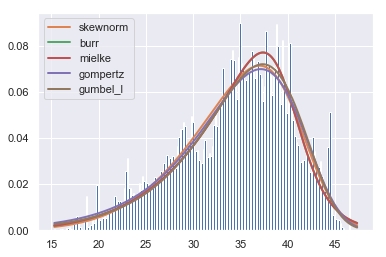

```python
f_SDCons.summary()
```

```python
# create synthetic data

SpatialDistributionConstraints_random_burr = burr.rvs(f_SDCons.fitted_param['burr'][0],
                                                      f_SDCons.fitted_param['burr'][1],
                                                      f_SDCons.fitted_param['burr'][2],
                                                      f_SDCons.fitted_param['burr'][3], len(df))

SpatialDistributionConstraints_ITS = inverse_transform_sampling(df['Spatial Distribution constraints (N,K Value)'])

SpatialDistributionConstraints_random_burr = SpatialDistributionConstraints_random_burr.astype(
                                    dtype = 'float32', casting = 'same_kind')

SpatialDistributionConstraints_ITS = SpatialDistributionConstraints_ITS.astype(
                                    dtype = 'float32', casting = 'same_kind')
```

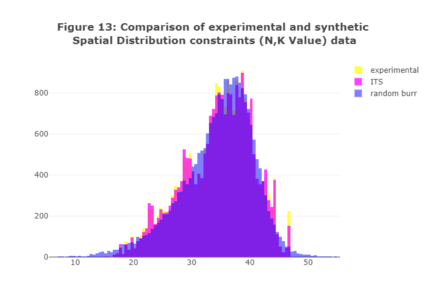

```python
trace_experimental = go.Histogram(x = df['Spatial Distribution constraints (N,K Value)'], opacity= 0.75,
                                  name = 'experimental',
                                  marker = dict(color = 'yellow'))

trace_ITS = go.Histogram(x = SpatialDistributionConstraints_ITS, opacity= 0.75,
                                  name = 'ITS',
                                  marker = dict(color = 'magenta'))

trace_random1 = go.Histogram(x = SpatialDistributionConstraints_random_burr, opacity= 0.5,
                                  name = 'random burr',
                                  marker = dict(color = 'blue'))

data = [trace_experimental, trace_ITS, trace_random1]

layout = go.Layout(barmode = 'overlay', title = '<b>Figure 13: Comparison of experimental and synthetic <br>' +
                   'Spatial Distribution constraints (N,K Value) data</b>')

fig = go.Figure(data=data, layout=layout)
# iplot(fig)
img_bytes = pio.to_image(fig, format='png')
Image(img_bytes)
```

## Discussion

By fitting different distributions for each of the variable in the CASP dataset, we have seen that for most of them, we can fit more than one distribution. In fact, as the figure below shows, [probability distributions are related to one another](https://en.wikipedia.org/wiki/Relationships_among_probability_distributions).

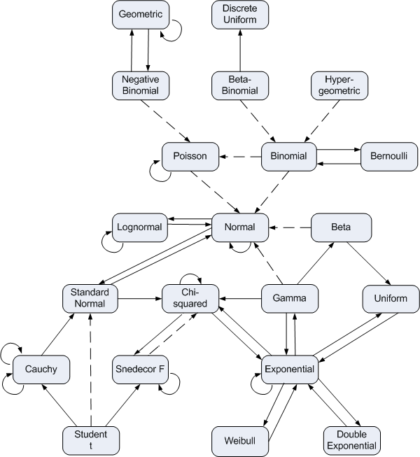

*Taken from the blog of [John D. Cook](https://www.johndcook.com/blog/distribution_chart/) with an original reference to [a paper by L. M. Leemis and J. T. McQueston](http://www.math.wm.edu/~leemis/2008amstat.pdf)*

In these instances, the most parsimonious model (*i.e.* having the least number of parameters) should be used as this will lower the risk of overfitting (or fitting the random noise). The AIC and BIC measures are a good criterion for penalizing the more complicated models.

Having synthesized all the variables separately with ITS and `scipy.stats` distributions, we can now collate them into Pandas dataframes, write the values to csv files for future reference and also visually compare them by using box plots.

```python
# because the numpy.ndarray values are horizontal and pd.DataFrame expects vertical arrangment,
# we have to transpose the arrays first if we are passing more than 1 ndarray.

# let's process the ITS datasets first

df_synthetic_ITS = pd.DataFrame(data = [RMSD_ITS, TotalArea_ITS, NonpolarExposedArea_ITS,
                                        FractionalAreaExposedNonPolarResidue_ITS,
                                        FractionalAreaExposedNonPolarPartOfResidue_ITS,
                                        MolecularMassWeightedExposedArea_ITS,
                                        AverageDeviationFromStandardExposedAreaOfResidue_ITS,
                                        EuclidianDistance_ITS, SecondaryStructurePenalty_ITS,
                                        SpatialDistributionConstraints_ITS]).T

# change the column headers to match the experimental columns
df_synthetic_ITS.columns = df.columns

# optimize data types

df_synthetic_ITS['RMSD'] = pd.to_numeric(df_synthetic_ITS['RMSD'], downcast='float')
df_synthetic_ITS['Total surface area'] = pd.to_numeric(df_synthetic_ITS['Total surface area'], downcast='unsigned')
df_synthetic_ITS['Non-polar exposed area'] = pd.to_numeric(df_synthetic_ITS['Non-polar exposed area'], downcast='float')

df_synthetic_ITS['Fractional area of exposed non-polar residue'] = pd.to_numeric(
    df_synthetic_ITS['Fractional area of exposed non-polar residue'], downcast='float')
df_synthetic_ITS['Fractional area of exposed non-polar part of residue'] = pd.to_numeric(
    df_synthetic_ITS['Fractional area of exposed non-polar part of residue'], downcast='float')

df_synthetic_ITS['Molecular mass weighted exposed area'] = pd.to_numeric(
    df_synthetic_ITS['Molecular mass weighted exposed area'], downcast='float')

df_synthetic_ITS['Average deviation from standard exposed area of residue'] = pd.to_numeric(
    df_synthetic_ITS['Average deviation from standard exposed area of residue'], downcast='float')

df_synthetic_ITS['Euclidian distance'] = pd.to_numeric(df_synthetic_ITS['Euclidian distance'], downcast='float')
df_synthetic_ITS['Secondary structure penalty'] = pd.to_numeric(
    df_synthetic_ITS['Secondary structure penalty'], downcast='unsigned')

df_synthetic_ITS['Spatial Distribution constraints (N,K Value)'] = pd.to_numeric(
    df_synthetic_ITS['Spatial Distribution constraints (N,K Value)'], downcast='float')

# write the dataframe to a csv file
df_synthetic_ITS.to_csv('CASP_synthetic_inverse_transform_sampling.csv')
```

```python
# do the same for rvs stuffs
# because we couldn't replicate RMSD by using a standard distribution, we'll take the one from ITS
# for cases with multiple distributions, we'll take the best one (lowest error + AIC/BIC)

df_synthetic_standardDistr = pd.DataFrame(data = [RMSD_ITS, TotalArea_random_moyal, NonpolarExposedArea_random_moyal,
                                        FractionalAreaExposedNonPolarResidue_random_johnsonsu,
                                        FractionalAreaExposedNonPolarPartOfResidue_random_exponnorm,
                                        MolecularMassWeightedExposedArea_random_moyal,
                                        AverageDeviationFromStandardExposedAreaOfResidue_random_exponnorm,
                                        EuclidianDistance_random_fisk, SecondaryStructurePenalty_random_invgauss,
                                        SpatialDistributionConstraints_random_burr]).T

df_synthetic_standardDistr.columns = df.columns

df_synthetic_standardDistr['RMSD'] = pd.to_numeric(df_synthetic_standardDistr['RMSD'], downcast='float')

df_synthetic_standardDistr['Total surface area'] = pd.to_numeric(
    df_synthetic_standardDistr['Total surface area'], downcast='unsigned')

df_synthetic_standardDistr['Non-polar exposed area'] = pd.to_numeric(
    df_synthetic_standardDistr['Non-polar exposed area'], downcast='float')

df_synthetic_standardDistr['Fractional area of exposed non-polar residue'] = pd.to_numeric(
    df_synthetic_standardDistr['Fractional area of exposed non-polar residue'], downcast='float')

df_synthetic_standardDistr['Fractional area of exposed non-polar part of residue'] = pd.to_numeric(
    df_synthetic_standardDistr['Fractional area of exposed non-polar part of residue'], downcast='float')

df_synthetic_standardDistr['Molecular mass weighted exposed area'] = pd.to_numeric(
    df_synthetic_standardDistr['Molecular mass weighted exposed area'], downcast='float')

df_synthetic_standardDistr['Average deviation from standard exposed area of residue'] = pd.to_numeric(
    df_synthetic_standardDistr['Average deviation from standard exposed area of residue'], downcast='float')

df_synthetic_standardDistr['Euclidian distance'] = pd.to_numeric(
    df_synthetic_standardDistr['Euclidian distance'], downcast='float')

df_synthetic_standardDistr['Secondary structure penalty'] = pd.to_numeric(
    df_synthetic_standardDistr['Secondary structure penalty'], downcast='unsigned')

df_synthetic_standardDistr['Spatial Distribution constraints (N,K Value)'] = pd.to_numeric(
    df_synthetic_standardDistr['Spatial Distribution constraints (N,K Value)'], downcast='float')

# write the dataframe to a csv file
df_synthetic_standardDistr.to_csv('CASP_synthetic_standard_distributions.csv')
```

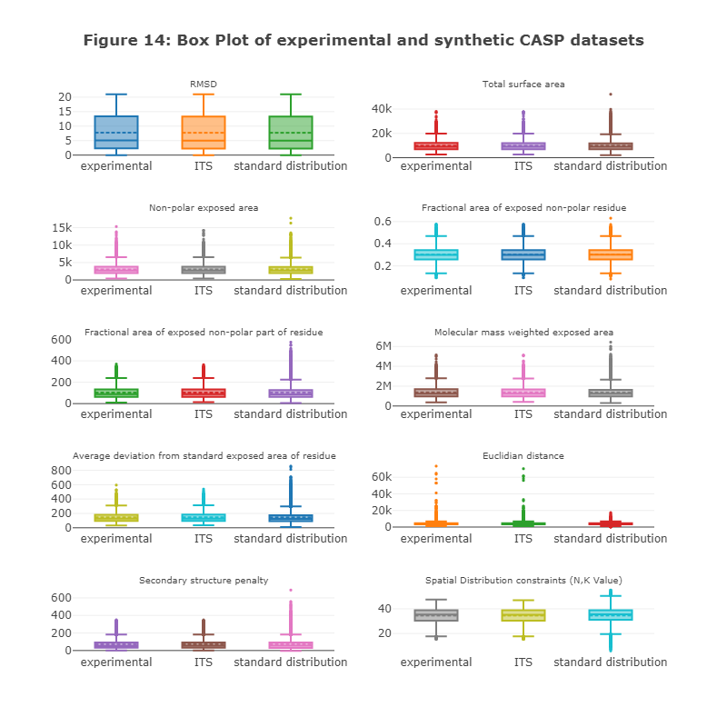

```python
trace_exp_0 = go.Box(y=df.iloc[:,0], marker = dict(size=3), name = 'experimental', boxmean = True)
trace_exp_1 = go.Box(y=df.iloc[:,1], marker = dict(size=3), name = 'experimental', boxmean = True)
trace_exp_2 = go.Box(y=df.iloc[:,2], marker = dict(size=3), name = 'experimental', boxmean = True)
trace_exp_3 = go.Box(y=df.iloc[:,3], marker = dict(size=3), name = 'experimental', boxmean = True)
trace_exp_4 = go.Box(y=df.iloc[:,4], marker = dict(size=3), name = 'experimental', boxmean = True)
trace_exp_5 = go.Box(y=df.iloc[:,5], marker = dict(size=3), name = 'experimental', boxmean = True)
trace_exp_6 = go.Box(y=df.iloc[:,6], marker = dict(size=3), name = 'experimental', boxmean = True)
trace_exp_7 = go.Box(y=df.iloc[:,7], marker = dict(size=3), name = 'experimental', boxmean = True)
trace_exp_8 = go.Box(y=df.iloc[:,8], marker = dict(size=3), name = 'experimental', boxmean = True)
trace_exp_9 = go.Box(y=df.iloc[:,9], marker = dict(size=3), name = 'experimental', boxmean = True)

trace_ITS_0 = go.Box(y=df_synthetic_ITS.iloc[:,0], marker = dict(size=3), name = 'ITS', boxmean = True)
trace_ITS_1 = go.Box(y=df_synthetic_ITS.iloc[:,1], marker = dict(size=3), name = 'ITS', boxmean = True)
trace_ITS_2 = go.Box(y=df_synthetic_ITS.iloc[:,2], marker = dict(size=3), name = 'ITS', boxmean = True)
trace_ITS_3 = go.Box(y=df_synthetic_ITS.iloc[:,3], marker = dict(size=3), name = 'ITS', boxmean = True)
trace_ITS_4 = go.Box(y=df_synthetic_ITS.iloc[:,4], marker = dict(size=3), name = 'ITS', boxmean = True)
trace_ITS_5 = go.Box(y=df_synthetic_ITS.iloc[:,5], marker = dict(size=3), name = 'ITS', boxmean = True)
trace_ITS_6 = go.Box(y=df_synthetic_ITS.iloc[:,6], marker = dict(size=3), name = 'ITS', boxmean = True)
trace_ITS_7 = go.Box(y=df_synthetic_ITS.iloc[:,7], marker = dict(size=3), name = 'ITS', boxmean = True)
trace_ITS_8 = go.Box(y=df_synthetic_ITS.iloc[:,8], marker = dict(size=3), name = 'ITS', boxmean = True)
trace_ITS_9 = go.Box(y=df_synthetic_ITS.iloc[:,9], marker = dict(size=3), name = 'ITS', boxmean = True)

trace_rvs_0 = go.Box(y=df_synthetic_standardDistr.iloc[:,0], marker = dict(size=3), name = 'standard distribution', boxmean = True)
trace_rvs_1 = go.Box(y=df_synthetic_standardDistr.iloc[:,1], marker = dict(size=3), name = 'standard distribution', boxmean = True)
trace_rvs_2 = go.Box(y=df_synthetic_standardDistr.iloc[:,2], marker = dict(size=3), name = 'standard distribution', boxmean = True)
trace_rvs_3 = go.Box(y=df_synthetic_standardDistr.iloc[:,3], marker = dict(size=3), name = 'standard distribution', boxmean = True)
trace_rvs_4 = go.Box(y=df_synthetic_standardDistr.iloc[:,4], marker = dict(size=3), name = 'standard distribution', boxmean = True)
trace_rvs_5 = go.Box(y=df_synthetic_standardDistr.iloc[:,5], marker = dict(size=3), name = 'standard distribution', boxmean = True)
trace_rvs_6 = go.Box(y=df_synthetic_standardDistr.iloc[:,6], marker = dict(size=3), name = 'standard distribution', boxmean = True)
trace_rvs_7 = go.Box(y=df_synthetic_standardDistr.iloc[:,7], marker = dict(size=3), name = 'standard distribution', boxmean = True)
trace_rvs_8 = go.Box(y=df_synthetic_standardDistr.iloc[:,8], marker = dict(size=3), name = 'standard distribution', boxmean = True)
trace_rvs_9 = go.Box(y=df_synthetic_standardDistr.iloc[:,9], marker = dict(size=3), name = 'standard distribution', boxmean = True)

# we have to make subplots because the scales are different for the variables
fig = tools.make_subplots(rows=5, cols=2, print_grid=False,
                          subplot_titles= (df.columns[0], df.columns[1], df.columns[2], df.columns[3],
                                           df.columns[4], df.columns[5], df.columns[6], df.columns[7],
                                           df.columns[8], df.columns[9]
                                                          ))

fig.append_trace(trace_exp_0, 1, 1)
fig.append_trace(trace_ITS_0, 1, 1)
fig.append_trace(trace_rvs_0, 1, 1)

fig.append_trace(trace_exp_1, 1, 2)
fig.append_trace(trace_ITS_1, 1, 2)
fig.append_trace(trace_rvs_1, 1, 2)

fig.append_trace(trace_exp_2, 2, 1)
fig.append_trace(trace_ITS_2, 2, 1)
fig.append_trace(trace_rvs_2, 2, 1)

fig.append_trace(trace_exp_3, 2, 2)
fig.append_trace(trace_ITS_3, 2, 2)
fig.append_trace(trace_rvs_3, 2, 2)

fig.append_trace(trace_exp_4, 3, 1)
fig.append_trace(trace_ITS_4, 3, 1)
fig.append_trace(trace_rvs_4, 3, 1)

fig.append_trace(trace_exp_5, 3, 2)
fig.append_trace(trace_ITS_5, 3, 2)
fig.append_trace(trace_rvs_5, 3, 2)

fig.append_trace(trace_exp_6, 4, 1)
fig.append_trace(trace_ITS_6, 4, 1)
fig.append_trace(trace_rvs_6, 4, 1)

fig.append_trace(trace_exp_7, 4, 2)
fig.append_trace(trace_ITS_7, 4, 2)
fig.append_trace(trace_rvs_7, 4, 2)

fig.append_trace(trace_exp_8, 5, 1)
fig.append_trace(trace_ITS_8, 5, 1)
fig.append_trace(trace_rvs_8, 5, 1)

fig.append_trace(trace_exp_9, 5, 2)
fig.append_trace(trace_ITS_9, 5, 2)
fig.append_trace(trace_rvs_9, 5, 2)

fig['layout'].update(height=800, width=800, title='<b>Figure 14: Box Plot of experimental and synthetic CASP datasets</b>')
fig['layout'].update(showlegend=False)

# https://github.com/plotly/plotly.py/issues/985
for i in fig['layout']['annotations']:
    i['font'] = dict(size=10)

# iplot(fig)
img_bytes = pio.to_image(fig, format='png')
Image(img_bytes)
```

From the comparative box plot above, the following can be noted:

1. both ITS and several of the standard probability distributions can be used to synthesize datasets that have similar characteristics as the experimental dataset
2. ITS provides a method for a more accurate data simulation compared to the standard distributions, due to simplified parametrization leading to constrained fitting of the experimental data to fit the model. This is especially so for a few variables where outliers (not present in the experimental dataset) were generated by the standard distribution methods.
3. for many variables, the ranges of synthesized data by standard distributions are much wider than the experimental and ITS datasets.

## Conclusion

Experimental dataset are valuable as they capture the nuances of the system under study. However, in many instances, it is not possible to obtain a large number of datapoints, especially when it involves long duration or high expenses. For those situations, it would be useful to generate a set of random values that resemble the experimental data. By having a combined 'experimental + synthetic' dataset, we can gain the ability to train machine learning algorithms, where highly-variant large datasets is a pre-requisite.

Similarly, the use of synthetic datasets helps in the case of parameter estimation for complex (highly parametrized) mechanistic models. Bayesian techniques such as Markov chain Monte Carlo (MCMC) simulations can be performed from a simulated dataset following a verification on the experimental dataset.

Through this notebook, we have learned how the CASP dataset is organized and the different abilities of `numpy.random` and `scipy.stats` libraries as well as their augmentation by inverse transform sampling.